# 2017/18 CHL Cleanup [I]

T.Hooker

20 February, 2019

```r
#options(table_counter=FALSE)
tidy_package <- c("plyr", "dplyr", "tidyr", "magrittr")
if(!"tidyr" %in% (.packages())) {invisible(lapply(tidy_package, library, character.only=T, quietly = T, warn.conflicts = F))}
# graph_package <- c("ggplot2", "scales")
options(scipen = 999, digits = 4, stringsAsFactors = FALSE, keep.source = TRUE)
##
#startwork.date <- format(Sys.Date(), "%y%m%d")
knitr::opts_chunk$set(cache=TRUE)
```

### Notes

This notebook compiles three (3) active files containing CHL data for the 2017 to 2018 period, performs cleanup and calculation steps, and prepares these data for import to AWMQS [190220]. Additional files may be used, as needed, to fill major gaps

## I: Import and Compile CHL Data

### 1.0 Import CHL-related Datafiles

#### 1.1 Import

```r
# files.01 <- choose.files(caption="Select DATA files [*.xlsx]", multi = TRUE)
CHL01_00 <- openxlsx::read.xlsx(files.01, sheet=1, colNames=T,
                                            rowNames=FALSE, check.names = T)
```

- Filename :: 2017wy_q3q4_LabDatPreImp_EDD10_190220_t2.xlsx
- Path :: U:/INFODATA/Sampling/Data_Cleanup_Scripts/Data_Review_Files/CHL_datafiles
- Last Accessed :: [2019-02-20 17:34:28]

```r
files.02 <- choose.files(caption="Select DATA files [*.xlsx]", multi = TRUE)
CHL02_00 <- openxlsx::read.xlsx(files.02, sheet=1, colNames=T,
                                            rowNames=FALSE, check.names = T)
```

- Filename :: EDD06dupes_XXX_ForReview_190220_t2.xlsx
- Path :: U:/INFODATA/Sampling/Data_Cleanup_Scripts/Data_Review_Files/CHL_datafiles
- Last Accessed :: [2019-02-20 17:34:37]

```r
# files.03 <- choose.files(caption="Select DATA files [*.xlsx]", multi = TRUE)
CHL03_00 <- openxlsx::read.xlsx(files.03, sheet=1, colNames=T,
                                            rowNames=FALSE, check.names = T)
```

- Filename :: EDD8_01_190128_SDaly_190220_t2.xlsx
- Path :: U:/INFODATA/Sampling/Data_Cleanup_Scripts/Data_Review_Files/CHL_datafiles
- Last Accessed :: [2019-02-20 17:34:41]

#### 1.2 Examine data structure and align field-names

```r
nam_CHL01 <- CHL01_00 %>% names(.)
nam_CHL02 <- CHL02_00 %>% names(.)
nam_CHL03 <- CHL03_00 %>% names(.)
#
length(nam_CHL01) <- max(length(nam_CHL01), length(nam_CHL02), length(nam_CHL03))
length(nam_CHL02) <- max(length(nam_CHL01), length(nam_CHL02), length(nam_CHL03))
length(nam_CHL03) <- max(length(nam_CHL01), length(nam_CHL02), length(nam_CHL03))
#
CHL_names <- as.data.frame(cbind(nam_CHL01, nam_CHL02, nam_CHL03))
#
openxlsx::write.xlsx(CHL_names, file="CHLfile_varnames_190220.xlsx")
```

- Update Key name-fields

```r
# comments <- readClipboard()
# Samp_set <- readClipboard()
# MethPar <- readClipboard() # ParamX = PARAM [new = old]
# SampleCollection <- readClipboard() # MLID2 = MLID
# ResultID <- readClipboard()
# Result_val <- readClipboard() # result.Value_MG = Result.Value ; Units2 = Units
# SampKeys <- readClipboard() # SKey6 = SKey2


## the remaining fields can just be maintained or separated (versioned) out

# comments
# Samp_set
# MethPar2 <- MethPar[MethPar != "PARAM"]
# SampleCollection2 <- SampleCollection[SampleCollection != "MLID2"]
# ResultID
# Result_val2 <- Result_val[Result_val != c("Result.Value_MG", "Units2")]
# SampKeys
```

#### 1.3 Extract Required fields

1. Dataset 01 :: CHL01_00
- No field-name changes needed for this dataset

```r
CHL01_01 <- CHL01_00 %>% mutate(FILE="CH01")
```

2. Dataset 02 :: CHL02_00

```r
CHL02_01 <- CHL02_00 %>% select(MLID_old = MLID, MLID = MLID2, everything()) %>%
    mutate(FILE="CH02", Project.Comment = as.character(Project.Comment))
```

3. Dataset 03 :: CHL03_00

```r
CHL03_01 <- CHL03_00 %>% select(ParamX = PARAM, Result.Value = Result.Value_MG,
                                Units.old = Units, Units = Units2, SKey2 = SKey6,
                                everything()) %>%
    mutate(FILE="CH03", Project.Comment = as.character(Project.Comment))
```

#### 1.4 Bind Datafiles

```r
CHL04_00 <- bind_rows(CHL02_01, CHL01_01, CHL03_01)
# class(CHL01_01$Project.Comment)
# class(CHL02_01$Project.Comment)
# class(CHL03_01$Project.Comment)
CHL04_00 %<>% select(FILE, Samp_set, SampleCollection2, ResultID,
                     MethPar2, Result_val2, SampKeys, comments, everything())
##
```

#### 1.5 Review Variables

```r
# data.file <- CHL04_00
data.file <- CHL04_01
#
Data.Vars <- data.frame()
for (i in 1:length(names(data.file))) {
  class_i <- class(data.file[,i])
  name_i <- names(data.file[i])
  num.NAs <- sum(is.na(data.file[,i]))
  count_levels <- as.numeric(length(unique((data.file[,i]))))
  num.blanks <- length(data.file[as.character(data.file[,i]) == "",c(i)]) # fixed for dates
  num.Obs <- nrow(data.file)-num.blanks
Data.Vars <- rbind(Data.Vars, data.frame(i, name_i, class_i, num.NAs, count_levels, num.blanks, num.Obs)) }
```

#### 1.6 Align Variables

0. Remove non-CHL related records

```r
CHL04_00 %>% distinct(Method.ID) %<>% arrange(.)
```

| Method.ID |
| --- |
| 200.8 |
| 350.1 |
| 365.1 |
| 160.2 |
| 160.4 |
| 325.2 |
| 245.1 |
| 353.2 |
| 160.1 |
| LACHAT |

[output cut: 30 more lines]

```r
CHL04_00 %>% {table(.$Method.ID, .$FILE, useNA="ifany")} %>%
    htmlTable::htmlTable(., css.cell = rbind(rep("padding-left: 0.8em; padding-right: 0.8em;font-size: 0.75em;",times=ncol(.)+1), matrix("padding-left: 0.75em; padding-right: 0.75em; font-size: 0.75em;", ncol=ncol(.)+1, nrow=nrow(.))))
```

|  | CH01 | CH02 | CH03 |
| --- | --- | --- | --- |
| 10200H | 2361 | 2037 | 3810 |
| 10300C | 25 | 18 | 0 |
| 120.1 | 346 | 322 | 0 |
| 150.1 | 67 | 7 | 0 |
| 160.1 | 2654 | 2289 | 0 |
| 160.2 | 2678 | 2338 | 0 |
| 160.4 | 1170 | 1096 | 0 |
| 1664 | 0 | 6 | 0 |
| 1694 | 0 | 21 | 0 |
| 180.1 | 397 | 270 | 0 |
| 200.8 | 37494 | 32298 | 0 |
| 2320B | 10500 | 5173 | 0 |
| 2340B | 44 | 0 | 0 |
| 245.1 | 1668 | 610 | 0 |
| 300 | 4 | 3 | 0 |
| 300.0 | 10 | 52 | 0 |
| 300.1 | 8 | 52 | 0 |
| 3114C | 390 | 107 | 0 |
| 325.2 | 2528 | 1294 | 0 |
| 350.1 | 3383 | 2667 | 0 |
| 353.2 | 5545 | 4563 | 0 |
| 365.1 | 5786 | 4776 | 0 |
| 370.1 | 6 | 52 | 0 |
| 375.2 | 1440 | 828 | 0 |
| 376.2 | 6 | 0 | 0 |
| 5210B | 444 | 591 | 0 |
| 5310B | 1095 | 1303 | 0 |
| 546 | 101 | 18 | 0 |
| 7471B | 11 | 0 | 0 |
| 8015B | 0 | 6 | 0 |
| 8260 | 0 | 106 | 0 |
| ANATOXIN | 0 | 242 | 0 |
| CYLINDROSPERMOPSIN | 0 | 1 | 0 |
| Explosives | 24 | 0 | 0 |
| HPLC | 105 | 0 | 38 |
| HPLCmod | 289 | 0 | 1456 |
| HPLCMOD | 0 | 4268 | 0 |
| LACHAT | 5088 | 4484 | 0 |
| MICROCYSTINS | 0 | 238 | 0 |
| QPCR | 0 | 172 | 0 |

```r
CHL_meth <- c("10200H", "10300C", "HPLC", "HPLCmod", "HPLCMOD")
##
CHL04_01 <- CHL04_00 %>% filter(Method.ID %in% CHL_meth)
# re-organize fields
CHL04_01 %<>% select(-Agency.Bill.Code, -Chain.of.Custody, -Collector, -Cost.Code,
                     -Sample.Type, everything())
```

1. Trips to Projects
   - Remove : TripID_x, Proj_nm

```r
unique(CHL04_01$Trip.ID)
```

```
  [1] "GSLWET2018"           "LAKES2018-082018"     "LAKES2018-050718"
  [4] "LAKES2018-181029"     "UTLK051518"           "UTLK061018"
  [7] "UTLK070918"           "UTLK080718"           "UTLK091718"
 [10] "UTLK100918"           "UTLK181113"           "UTAHLAKE062217"
 [13] "BYUUL070617"          "BYUUL071817"          "BYUUL072717"
 [16] "BYUUL080317"          "BYUUL081617"          "BYUUL082217"
 [19] "BYUUL082917"          "BYUUL090517"          "BYUUL092617"
 [22] "BYUUL100317"          "UTLK101518"           "LAKES2018-090418"
 [25] "LAKES2018-091018"     "UTAHLAKE021418"       "UTAHLAKE031218"
 [28] "UTLK041818"           "UTAHLAKES2018-043018" "LAKES2018-052118"
 [31] "LAKES2018-052818"     "LAKES2018-060418"     "LAKES2018-061218"
 [34] "LAKES2018-061818"     "LAKES2018070918"      "LAKES2018-073018"
 [37] "LAKES2018-080618"     "LAKES2018-081318"     "LAKES2018-082718"
 [40] "LAKES2018-092418"     "UTLK181210"           "LAKES2018-072318"
 [43] "LAKES2018-051418"     "JRULI050718"          "JRULI061118"
```

[output cut: 19 more lines]

```r
unique(CHL04_01$TripID.3)
```

```
 [1] NA                 "UTAHLAKE011018"   "UL061217"         "UTAHLAKE081417"
 [5] "UTAHLAKE122017"   "UTAHLAKE110617"   "UCASE2017"        "LAKES2017"
 [9] "LAKES2017072417"  "LAKES2017073117"  "LAKES2017080717"  "LAKES2017081417"
[13] "LAKES2017082117"  "LAKES2017082817"  "LAKES2017090417"  "LAKES2017091217"
[17] "LAKES2017091817"  "LAKES2017092517"  "LAKES2017100217"  "UTAHLAKE100917"
[21] "LAKES2017101017"  "LAKES2017101617"  "LAKES2017102317"  "LAKEES2017080717"
[25] "UTAHLAKE091117"   "UBI091117"        "GSLWET2017"       "UL071017"
[29] "UBI071017"        "UBI082117"        "BORFG170808"      "WS072717"
[33] "LAKES2017070317"  "LAKES2017061917"  "UBI061217"        "LAKES2017062617"
[37] "LAKES2017071017"  "LAKES2017061217"  "LAKES2017060517"  "BORFG170605"
[41] "UBI051517"        "LAKES2017052217"  "UL050817"         "LAKES050817"
```

```r
unique(CHL04_01$TripID_x)
```

```
 [1] NA                     "GSLWET2018"           "LAKES2017-060517"
 [4] "LAKES2018-050718"     "UCASE2017"            "LAKES2017-102317"
 [7] "UCASE2016"            "UL050817"             "UL061217"
[10] "HABS111516"           "BYUUL070617"          "BYUUL071817"
[13] "BYUUL072717"          "BYUUL080317"          "BYUUL081617"
[16] "BYUUL082217"          "BYUUL082917"          "BYUUL090517"
[19] "BYUUL092617"          "BYUUL100317"          "UTAHLAKE062217"
[22] "UL071017"             "UTAHLAKE081417"       "UTAHLAKE091117"
[25] "UTAHLAKE100917"       "LAKES050817"          "LAKES2017-080717"
[28] "LAKES2017-061917"     "LAKES2017"            "WRI081516"
[31] "LAKES2017-061217"     "LAKES2017-052217"     "LAKES2017-062617"
[34] "LAKES2017-070317"     "LAKEES2017-080717"    "LAKES2017-082117"
[37] "LAKES2017-090417"     "LAKES2017-091817"     "LAKES2017-092517"
[40] "LAKES2017-100217"     "UTAHLAKE110617"       "LAKES2018-052118"
[43] "LAKES2018-052818"     "LAKES2018-060418"     "LAKES2018-061218"
[46] "LAKES2018-061818"     "LAKES2018070918"      "LAKES2018-073018"
[49] "LAKES2018-080618"     "LAKES2018-081318"     "UBI051517"
[52] "UBI061217"            "UBI071017"            "UBI082117"
[55] "UBI091117"            "LAKES2017-072417"     "LAKES2017-073117"
[58] "LAKES2017-082817"     "LAKES2017-101617"     "LAKES2018-072318"
[61] "BORFG170605"          "BOR FG 170808"        "BORFG170808"
[64] "LAKES2017-071017"     "LAKES2018-051418"     "GSLWET2017"
[67] "JRULI050718"          "JRULI061118"          "JRULI070918"
[70] "JRULI081318"          "UTAHLAKE122017"       "UTAHLAKE011018"
[73] "UTAHLAKE021418"       "UTAHLAKE031218"       "UTLK041818"
[76] "UTAHLAKES2018-043018" "UCASE2018"            "UTLK051518"
[79] "UTLK061018"           "UTLK070918"           "LAKES2017091217"
[82] "LAKES2018-071618"     "LAKES2017-081417"     "LAKES2017-101017"
[85] "WS072717"
```

```r
CHL04_01 %>% {table(is.na(.$Trip.ID), is.na(.$TripID.3), useNA="ifany", deparse.level = 2)}
```

```
                is.na(.$TripID.3)
is.na(.$Trip.ID) FALSE TRUE
           FALSE  2446 8243
           TRUE      0 3718
```

```r
CHL04_01 %>% {table(is.na(.$Trip.ID), is.na(.$TripID_x), useNA="ifany")}
```

```
        FALSE TRUE
  FALSE  4288 6401
  TRUE   1016 2702
```

```r
CHL04_01 %>% {table(is.na(.$TripID_x), is.na(.$TripID.3), useNA="ifany")}
```

```
        FALSE TRUE
  FALSE     0 5304
  TRUE   2446 6657
```

```r
CHL04_01 %<>% mutate(Trip_root = as.character(NA)) %>% mutate(
    Trip_root = case_when(
        !is.na(Trip.ID) ~ substr(.$Trip.ID, 1,
                                 (stringr::str_locate(.$Trip.ID,
                                                      "[0-9]")[,1])-1),
        !is.na(TripID.3) ~ substr(.$TripID.3, 1,
                                 (stringr::str_locate(.$TripID.3,
                                                      "[0-9]")[,1])-1),
        !is.na(TripID_x) ~ substr(.$TripID_x, 1,
                                 (stringr::str_locate(.$TripID_x,
                                                      "[0-9]")[,1])-1),
        TRUE ~ as.character(NA)) ) %>% select(FILE:SType2, Trip_root, everything())
CHL04_01 %<>% mutate(Trip_root = gsub(" ", "", .$Trip_root))
CHL04_01 %>% {sort(unique(.$Trip_root))}
```

```
 [1] "BORFG"     "BYUUL"     "GSLWET"    "HABS"      "JRULI"     "LAKEES"    "LAKES"
 [8] "UBI"       "UCASE"     "UL"        "UTAHLAKE"  "UTAHLAKES" "UTLK"      "WRI"
[15] "WS"
```

```r
CHL04_01 %<>% select(-TripID.2, -TripID_x, -Proj_nm, -Proj_GRP, everything())
```

- Re-code any Trips similar to *Utah Lake* to `UTLK`

```r
utlk_trips <- c("UTLK", "UTAHLAKE", "UTAHLAKES", "UL")
#
CHL04_01 %<>% mutate(
    Trip_root = case_when(
        !is.na(Trip_root) & Trip_root %in% utlk_trips ~ "UTLK",
        !is.na(Trip_root) & Trip_root == "LAKEES" ~ "LAKES",
        !is.na(Trip_root) ~ Trip_root,
        is.na(Trip_root) ~ as.character(NA)) )
CHL04_01 %>% {sort(unique(.$Trip_root))}
```

```
 [1] "BORFG"  "BYUUL"  "GSLWET" "HABS"   "JRULI"  "LAKES"  "UBI"    "UCASE"  "UTLK"
[10] "WRI"    "WS"
```

```r
#
CHL04_01 %>% {addmargins(table(.$Trip_root, .$FILE, useNA="ifany", deparse.level = 2))} %>%
    htmlTable::htmlTable(., css.cell = rbind(rep("padding-left: 0.8em; padding-right: 0.8em;font-size: 0.75em;",times=ncol(.)+1), matrix("padding-left: 0.75em; padding-right: 0.75em; font-size: 0.75em;", ncol=ncol(.)+1, nrow=nrow(.))))
```

|  | .$FILE CH01 | .$FILE CH02 | .$FILE CH03 |  | Sum |
| --- | --- | --- | --- | --- | --- |
| .$Trip_root |  |  |  |  |  |
| BORFG | 48 | 0 | 64 |  | 112 |
| BYUUL | 0 | 420 | 168 |  | 588 |
| GSLWET | 48 | 120 | 197 |  | 365 |
| HABS | 0 | 0 | 9 |  | 9 |
| JRULI | 0 | 627 | 507 |  | 1134 |
| LAKES | 630 | 357 | 1100 |  | 2087 |
| UBI | 360 | 0 | 484 |  | 844 |
| UCASE | 163 | 114 | 354 |  | 631 |
| UTLK | 1185 | 2245 | 2377 |  | 5807 |
| WRI | 0 | 0 | 24 |  | 24 |
| WS | 12 | 32 | 20 |  | 64 |
| NA | 334 | 2408 | 0 |  | 2742 |
| Sum | 2780 | 6323 | 5304 |  | 14407 |

```r
CHL04_01 %>% filter(is.na(Trip_root))
```

| FILE | Lab.filename | Project.Name | Sample.Received.Date | SType2 | Trip_root | Trip.ID | TripID.3 | SDate_x | Sample.Time | Sample.Date | MLID | Station.ID | QC.parent | QC_type | MLID.type | MLID_name | MLID_x | Sample.Description | Sample.Number | Analysis.Date | Batch.Number | Dilution.Factor | Replicate.Number | SNum_x | Test.Number | Method.Agency | Method.Description | Method.ID | Method_x | … |
| --- | --- | --- | --- | --- | --- | --- | --- | --- | --- | --- | --- | --- | --- | --- | --- | --- | --- | --- | --- | --- | --- | --- | --- | --- | --- | --- | --- | --- | --- | --- |
| CH02 | UDWQ_EDD_20180525.txt | C2018-00769 | 43168 | NA | NA | NA | NA | NA | 09:00 | 43168 | CHL_samp | NA | NA | NA | NA | NA | NA | 2092710 | 2115736 | 43171 | CHLA-20180312-1 | 1 | 1 | NA | 10256322 | UPHL | CHLOROPHYLL A BY HPLC | HPLCMOD | NA | … |
| CH02 | UDWQ_EDD_20180601.txt | C2018-00770 | 43168 | NA | NA | NA | NA | NA | 9:00 | 43168 | CHL_samp | NA | NA | NA | NA | NA | NA | 2092712 | 2115737 | 43171 | CHLA-20180312-1 | 1 | 1 | NA | 10256323 | UPHL | CHLOROPHYLL A BY HPLC | HPLCMOD | NA | … |
| CH02 | UDWQ_EDD_20180601.txt | C2018-00771 | 43168 | NA | NA | NA | NA | NA | 9:00 | 43168 | CHL_samp | NA | NA | NA | NA | NA | NA | 2092713 | 2115738 | 43171 | CHLA-20180312-1 | 1 | 1 | NA | 10256324 | UPHL | CHLOROPHYLL A BY HPLC | HPLCMOD | NA | … |
| CH02 | UDWQ_EDD_20180601.txt | C2018-00772 | 43168 | NA | NA | NA | NA | NA | 9:00 | 43168 | CHL_samp | NA | NA | NA | NA | NA | NA | 2092748 | 2115739 | 43171 | CHLA-20180312-1 | 1 | 1 | NA | 10256325 | UPHL | CHLOROPHYLL A BY HPLC | HPLCMOD | NA | … |
| CH02 | UDWQ_EDD_20180601.txt | C2018-00773 | 43168 | NA | NA | NA | NA | NA | 9:00 | 43168 | CHL_samp | NA | NA | NA | NA | NA | NA | 2092751 | 2115740 | 43171 | CHLA-20180312-1 | 1 | 1 | NA | 10256326 | UPHL | CHLOROPHYLL A BY HPLC | HPLCMOD | NA | … |
| CH02 | UDWQ_EDD_20180601.txt | C2018-00774 | 43168 | NA | NA | NA | NA | NA | 9:00 | 43168 | CHL_samp | NA | NA | NA | NA | NA | NA | 2093160 | 2115741 | 43171 | CHLA-20180312-1 | 1 | 1 | NA | 10256327 | UPHL | CHLOROPHYLL A BY HPLC | HPLCMOD | NA | … |
| CH02 | UDWQ_EDD_20180601.txt | C2018-00775 | 43168 | NA | NA | NA | NA | NA | 9:00 | 43168 | CHL_samp | NA | NA | NA | NA | NA | NA | 2093161 | 2115742 | 43171 | CHLA-20180312-1 | 1 | 1 | NA | 10256328 | UPHL | CHLOROPHYLL A BY HPLC | HPLCMOD | NA | … |
| CH02 | UDWQ_EDD_20180601.txt | C2018-00775 | 43168 | NA | NA | NA | NA | NA | 9:00 | 43168 | CHL_samp | NA | NA | NA | NA | NA | NA | 2093161 | 2115742 | 43171 | CHLA-20180312-1 | 10 | 2 | NA | 10267677 | UPHL | CHLOROPHYLL A BY HPLC | HPLCMOD | NA | … |
| CH02 | UDWQ_EDD_20180601.txt | C2018-00776 | 43168 | NA | NA | NA | NA | NA | 9:00 | 43168 | CHL_samp | NA | NA | NA | NA | NA | NA | 2093162 | 2115743 | 43171 | CHLA-20180312-1 | 1 | 1 | NA | 10256329 | UPHL | CHLOROPHYLL A BY HPLC | HPLCMOD | NA | … |
| CH02 | UDWQ_EDD_20180601.txt | C2018-00777 | 43168 | NA | NA | NA | NA | NA | 9:00 | 43168 | CHL_samp | NA | NA | NA | NA | NA | NA | 2093163 | 2115744 | 43171 | CHLA-20180312-1 | 1 | 1 | NA | 10256330 | UPHL | CHLOROPHYLL A BY HPLC | HPLCMOD | NA | … |

[output cut: 990 more lines]

- Sample Times will need to be re-aligned… (re-formatted)
2. Station.ID : MLID : MLID_x (chl_method_corrected)
   - Build Order :: Station.ID, MLID, MLID_x
   - Move QC and MLID.type and MLID_name to back
     - Will Re-lookup these from MonLoc later

```r
CHL04_01 %<>% select(FILE:Sample.Date, Station.ID, MLID, MLID_x, everything())
CHL04_01 %>% filter(is.na(Station.ID)) %>%
    {addmargins(table(.$MLID, is.na(.$Station.ID), useNA="ifany"))}
```

```
           TRUE  Sum
  4917343     3    3
  4995120     3    3
  CHL_samp 2368 2368
  CHL_test  334  334
  NoMLID     40   40
  <NA>     1034 1034
  Sum      3782 3782
```

- When `MLID` == “CHL_samp” :: Record is a re-analysis using a 2nd CHL method
- MLID & MLID_x can be combinateD(mutually exclusive), *iff* `Station.ID` == *NULL*
  - Convert all to **MLID_00** (from MLID_x or Station.ID)

```r
CHL04_01 %<>% mutate(MLID_00 = as.character(NA)) %>% mutate(
    MLID_00 = case_when(
        !is.na(Station.ID) ~ as.character(Station.ID),
        !is.na(MLID) ~ as.character(MLID),
        !is.na(MLID_x) ~ as.character(MLID_x),
        TRUE ~ as.character(NA))) %>%
    select(FILE:Sample.Date, MLID_00, everything()) %>%
    select(-Station.ID, -MLID, -MLID_x, -QC.parent, everything())
# Looks like no records w/ missing `MLID_00`
sum(is.na(CHL04_01$MLID_00))
```

```
[1] 0
```

3. Sample.Number : SNum_x (chl_method_corrected)
   - Make sure that SampNums are extracted from Sample.Descriptions

```r
# no records are missing Sample.Number
sum(is.na(CHL04_01$Sample.Number))
```

```
[1] 0
```

```r
# unique(CHL04_01$Sample.Number)
max(nchar(CHL04_01$Sample.Number))
```

```
[1] 7
```

```r
sd(nchar(CHL04_01$Sample.Number))
```

```
[1] 0
```

```r
##
CHL04_01 %<>% select(-MLID.type, -MLID_name, -Sample.Description, everything()) %>%
    select(FILE:Sample.Number, SNum_x, everything())
```

#### 1.61 Align Vars (2)

4. Align Method.IDs
   - Integrate Sample.Matrix / Samp.Matrix (*or drop*)
   - Populate ParamX

```r
CHL04_01 %>% {table(.$Method.ID, .$Method.GRP, useNA="ifany")}
```

```
           CHL CHL_hplc Filter <NA>
  10200H  4398        0      0 3810
  10300C     0        0     43    0
  HPLC       0      105      0   38
  HPLCmod    0      289      0 1456
  HPLCMOD    0     4268      0    0
```

```r
#
CHL04_02 <- mutate(CHL04_01,
    Method.GRP = case_when(
        is.na(Method.GRP) & Method.ID == "10200H" ~  "CHL",
        is.na(Method.GRP) & Method.ID == "10300C" ~  "Filter",
        is.na(Method.GRP) & Method.ID == "HPLC" ~  "CHL_hplc",
        is.na(Method.GRP) & Method.ID == "HPLCmod" ~  "CHL_hplc",
        is.na(Method.GRP) & Method.ID == "HPLCMOD" ~  "CHL_hplc",
        !is.na(Method.GRP) ~ Method.GRP,
        TRUE ~ as.character(NA)))
#
CHL04_02 %>% {table(.$Method.ID, .$Method.GRP, useNA="ifany")}
```

```
           CHL CHL_hplc Filter
  10200H  8208        0      0
  10300C     0        0     43
  HPLC       0      143      0
  HPLCmod    0     1745      0
  HPLCMOD    0     4268      0
```

```r
# little cleanup
CHL04_02 %<>% select(-Method_x, -Method.Description, -Method.Agency, everything())
```

```r
CHL04_02 %>% {table(.$Sample.Matrix, .$FILE, useNA="ifany")}
```

```
       CH01 CH02 CH03
  X       0 6323    0
  <NA> 2780    0 5304
```

```r
CHL04_02 %>% {table(.$Samp.Matrix, .$FILE, useNA="ifany")}
```

```
       CH01 CH02 CH03
  X    2780    0    0
  <NA>    0 6323 5304
```

```r
CHL04_02 %>% {table(.$Matrix.Description, .$FILE, useNA="ifany")}
```

```
         CH01 CH02 CH03
  Filter 2780 6323 5304
```

```r
#
CHL04_02 %<>% mutate(
    Sample.Matrix = recode(Matrix.Description, "Filter" = "X")) %>%
    select(-Matrix.Description, -Samp.Matrix, -TripID.3, -Dilution.Factor,
           -Replicate.Number, everything())
```

```r
# Any missing Parameter names?
sum(is.na(CHL04_02$Param.Description))
```

```
[1] 0
```

```r
# Any missing parameter-name conversions?
sum(is.na(CHL04_02$ParamX))
```

```
[1] 0
```

```r
CHL04_02 %>% {table(.$Param.Description, .$ParamX, useNA="ifany")}
```

```
                            CHL.tot CHL_vol CHLa CHLA CHLA.aa CHLA.ba CHLa_c PERI Pheo PHEO
  Chlorophyll-a                   0       0   83  747       0       0      0    0    0    0
  CHLOROPHYLL-A                   0       0  965    0       0       0      0    0    0    0
  Chlorophyll-a (conc)            0       0    0    0       0       0     76    0    0    0
  CHLOROPHYLL-A (CONC)            0       0    0    0       0       0    779    0    0    0
  Chlorophyll-A After Acid        0       0    0 1270     787       0      0    0    0    0
  CHLOROPHYLL-A AFTER ACID        0       0    0    0     679       0      0    0    0    0
  Chlorophyll-A Before Acid    1270       0    0    0       0     787      0    0    0    0
  CHLOROPHYLL-A BEFORE ACID       0       0    0    0       0     679      0    0    0    0
  Filtered Volume                 0      76    0    0       0       0      0    0    0    0
  FILTERED VOLUME                 0     780    0    0       0       0      0    0    0    0
  Periphyton                      0       0    0    0       0       0      0   25    0    0
  PERIPHYTON                      0       0    0    0       0       0      0   18    0    0
  Pheophytin                      0       0    0    0       0       0      0    0  787    0
  PHEOPHYTIN                      0       0    0    0       0       0      0    0  679    0
  Pheophytin-a                    0       0    0    0       0       0      0    0    0   83
  PHEOPHYTIN-A                    0       0    0    0       0       0      0    0    0  965
  Pheophytin-a (conc)             0       0    0    0       0       0      0    0    0    0
  PHEOPHYTIN-A (CONC)             0       0    0    0       0       0      0    0    0    0

                            PHEO_c PHEOA
  Chlorophyll-a                  0     0
  CHLOROPHYLL-A                  0     0
  Chlorophyll-a (conc)           0     0
  CHLOROPHYLL-A (CONC)           0     0
  Chlorophyll-A After Acid       0     0
  CHLOROPHYLL-A AFTER ACID       0     0
  Chlorophyll-A Before Acid      0     0
  CHLOROPHYLL-A BEFORE ACID      0     0
  Filtered Volume                0     0
  FILTERED VOLUME                0     0
  Periphyton                     0     0
  PERIPHYTON                     0     0
  Pheophytin                     0  1270
  PHEOPHYTIN                     0     0
  Pheophytin-a                   0   747
  PHEOPHYTIN-A                   0     0
  Pheophytin-a (conc)           76     0
  PHEOPHYTIN-A (CONC)          779     0
```

```r
# CHL04_01 %>% {table(.$Param.Description, .$FILE, useNA="ifany")}
CHL04_02 %>% {table(.$Param.Description, .$Method.GRP, useNA="ifany")}
```

```
                             CHL CHL_hplc Filter
  Chlorophyll-a                0      830      0
  CHLOROPHYLL-A                0      965      0
  Chlorophyll-a (conc)         0       76      0
  CHLOROPHYLL-A (CONC)         0      779      0
  Chlorophyll-A After Acid  2057        0      0
  CHLOROPHYLL-A AFTER ACID   679        0      0
  Chlorophyll-A Before Acid 2057        0      0
  CHLOROPHYLL-A BEFORE ACID  679        0      0
  Filtered Volume              0       76      0
  FILTERED VOLUME              0      780      0
  Periphyton                   0        0     25
  PERIPHYTON                   0        0     18
  Pheophytin                2057        0      0
  PHEOPHYTIN                 679        0      0
  Pheophytin-a                 0      830      0
  PHEOPHYTIN-A                 0      965      0
  Pheophytin-a (conc)          0       76      0
  PHEOPHYTIN-A (CONC)          0      779      0
```

- Need to develop a more consistent conversion of parameter names, regardless of method

```r
# CHL04_01 %<>% mutate(
    # ParamX = recode(ParamX, "CHLa" = "CHLA","CHLA.aa" = "CHLA_aa","CHLA.ba" = "CHLA_ba",
    #                 "CHLa_c" = "CHLA_c","Pheo" = "PHEO"))
##
## Build from Param.Description instead (of above)
##
CHL04_02 %<>% mutate(
    ParamX = recode(ParamX,
                    "Chlorophyll-a" = "CHLA",
                    "CHLOROPHYLL-A" = "CHLA",
                    "Chlorophyll-a (conc)" = "CHLA_c",
                    "CHLOROPHYLL-A (CONC)" = "CHLA_c",
                    "Chlorophyll-A After Acid" = "CHLA",
                    "CHLOROPHYLL-A AFTER ACID" = "CHLA",
                    "Chlorophyll-A Before Acid" = "CHL.tot",
                    "CHLOROPHYLL-A BEFORE ACID" = "CHL.tot",
                    "Filtered Volume" = "c_VOL",
                    "FILTERED VOLUME" = "c_VOL",
                    "Periphyton" = "PERI",
                    "PERIPHYTON" = "PERI",
                    "Pheophytin" = "PHEO",
                    "PHEOPHYTIN" = "PHEO",
                    "Pheophytin-a" = "PHEO",
                    "PHEOPHYTIN-A" = "PHEO",
                    "Pheophytin-a (conc)" = "PHEO_c",
                    "PHEOPHYTIN-A (CONC)" = "PHEO_c",
                    "CHLa" = "CHLA",
                    "CHLA.aa" = "CHLA",
                    "CHLA.ba" = "CHL.tot",
                    "CHLa_c" = "CHLA_c",
                    "Pheo" = "PHEO",
                    "PHEOA" = "PHEO",
                    "CHL_vol" = "c_VOL"
                    ) )
##
CHL04_02 %>% {table(.$Param.Description, .$ParamX, useNA="ifany")}
```

```
                            c_VOL CHL.tot CHLA CHLA_c PERI PHEO PHEO_c
  Chlorophyll-a                 0       0  830      0    0    0      0
  CHLOROPHYLL-A                 0       0  965      0    0    0      0
  Chlorophyll-a (conc)          0       0    0     76    0    0      0
  CHLOROPHYLL-A (CONC)          0       0    0    779    0    0      0
  Chlorophyll-A After Acid      0       0 2057      0    0    0      0
  CHLOROPHYLL-A AFTER ACID      0       0  679      0    0    0      0
  Chlorophyll-A Before Acid     0    2057    0      0    0    0      0
  CHLOROPHYLL-A BEFORE ACID     0     679    0      0    0    0      0
  Filtered Volume              76       0    0      0    0    0      0
  FILTERED VOLUME             780       0    0      0    0    0      0
  Periphyton                    0       0    0      0   25    0      0
  PERIPHYTON                    0       0    0      0   18    0      0
  Pheophytin                    0       0    0      0    0 2057      0
  PHEOPHYTIN                    0       0    0      0    0  679      0
  Pheophytin-a                  0       0    0      0    0  830      0
  PHEOPHYTIN-A                  0       0    0      0    0  965      0
  Pheophytin-a (conc)           0       0    0      0    0    0     76
  PHEOPHYTIN-A (CONC)           0       0    0      0    0    0    779
```

5. Filtration Volumes
   - Benthic & Filt.Vol.LUT & VOL_filt

```r
CHL04_02 %>% {addmargins(table(is.na(.$VOL_filt), is.na(.$Filt.Vol.LUT), useNA="ifany"))}
```

```
        FALSE  TRUE   Sum
  FALSE   438  4170  4608
  TRUE     12  9787  9799
  Sum     450 13957 14407
```

```r
CHL04_02 %>% {addmargins(table(is.na(.$Filt.Vol.LUT), .$FILE,useNA="ifany"))}
```

```
         CH01  CH02  CH03   Sum
  FALSE     0     0   450   450
  TRUE   2780  6323  4854 13957
  Sum    2780  6323  5304 14407
```

```r
CHL04_02 %>% {addmargins(table(is.na(.$VOL_filt), .$FILE,useNA="ifany"))}
```

```
         CH01  CH02  CH03   Sum
  FALSE     0     0  4608  4608
  TRUE   2780  6323   696  9799
  Sum    2780  6323  5304 14407
```

```r
#
CHL04_03 <- mutate(CHL04_02,
    VOL_filt = case_when(
        is.na(VOL_filt) & !is.na(Filt.Vol.LUT) & (Filt.Vol.LUT != 0) ~ as.character(Filt.Vol.LUT),
        !is.na(VOL_filt) ~ as.character(VOL_filt))) %>%
    mutate(VOL_filt = as.numeric(VOL_filt)) %>%
    select(-Filt.Vol.LUT, everything())
CHL04_03 %>% {addmargins(table(.$VOL_filt, .$FILE,useNA="ifany"))}
```

```
        CH01  CH02  CH03   Sum
  100      0     0   126   126
  150      0     0   156   156
  170      0     0     5     5
  200      0     0    34    34
  250      0     0  1611  1611
  300      0     0    28    28
  350      0     0   114   114
  400      0     0    54    54
  450      0     0    18    18
  500      0     0  2024  2024
  550      0     0     6     6
  600      0     0    14    14
  625      0     0     3     3
  650      0     0     5     5
```

[output cut: 27 more lines]

```r
CHL04_03 %>% {addmargins(table(.$Benthic, .$FILE, useNA="ifany"))}
```

```
                    CH01  CH02  CH03   Sum
  15/                  0     0     6     6
  15/15                0     0    60    60
  25/                  0     0    60    60
  25/25                0     0   190   190
  25/25 benth+afdm     0     0     6     6
  none                 0     0     6     6
  <NA>              2780  6323  4976 14079
  Sum               2780  6323  5304 14407
```

6. Result.Value : RV2_ug && Units
- Working dataframe :: `CHL04_03` [190221]
- Note: `Units.old` applies only to CH03 file

```r
select(CHL04_03, contains("Unit", ignore.case = T)) %>% names(.)
```

```
[1] "Units"     "Units.old"
```

```r
CHL04_03 %<>% select(FILE:Units, Units.old, everything())
#
CHL04_03 %>% {addmargins(table(is.na(.$Result.Value), is.na(.$RV2_ug), useNA="ifany"))}
```

```
        FALSE  TRUE   Sum
  FALSE  5304  9103 14407
  Sum    5304  9103 14407
```

```r
CHL04_03 %>% {addmargins(table(is.na(.$RV2_ug), .$Units, useNA="ifany"))}
```

```
           MG MG-M-SQ    ML    UG  UG-L   Sum
  FALSE     0       0     0  5304     0  5304
  TRUE   4398      43   856  2096  1710  9103
  Sum    4398      43   856  7400  1710 14407
```

```r
CHL04_03 %>% {addmargins(table(is.na(.$RV2_ug), .$Units.old, useNA="ifany"))}
```

```
           MG    UG  <NA>   Sum
  FALSE  3810  1494     0  5304
  TRUE      0     0  9103  9103
  Sum    3810  1494  9103 14407
```

```r
CHL04_03 %>% {addmargins(table(is.na(.$Result.Value), .$Units, useNA="ifany"))}
```

```
           MG MG-M-SQ    ML    UG  UG-L   Sum
  FALSE  4398      43   856  7400  1710 14407
  Sum    4398      43   856  7400  1710 14407
```

```r
CHL04_03 %>% {addmargins(table(is.na(.$Result.Value), .$Units.old, useNA="ifany"))}
```

```
           MG    UG  <NA>   Sum
  FALSE  3810  1494  9103 14407
  Sum    3810  1494  9103 14407
```

```r
CHL04_03 %>% {addmargins(table(.$Units, .$Units.old, useNA="ifany", deparse.level = 2))}
```

```
         .$Units.old
.$Units      MG    UG  <NA>   Sum
  MG          0     0  4398  4398
  MG-M-SQ     0     0    43    43
  ML          0     0   856   856
  UG       3810  1494  2096  7400
  UG-L        0     0  1710  1710
  Sum      3810  1494  9103 14407
```

```r
CHL04_03 %>% {addmargins(table(paste(.$Units.old, .$Units, sep="_"), .$FILE, useNA="ifany", deparse.level = 2))}
```

```
                                      .$FILE
paste(.$Units.old, .$Units, sep = "_")  CH01  CH02  CH03   Sum
                            MG_UG          0     0  3810  3810
                            NA_MG       2361  2037     0  4398
                            NA_MG-M-SQ    25    18     0    43
                            NA_ML         76   780     0   856
                            NA_UG        166  1930     0  2096
                            NA_UG-L      152  1558     0  1710
                            UG_UG          0     0  1494  1494
                            Sum         2780  6323  5304 14407
```

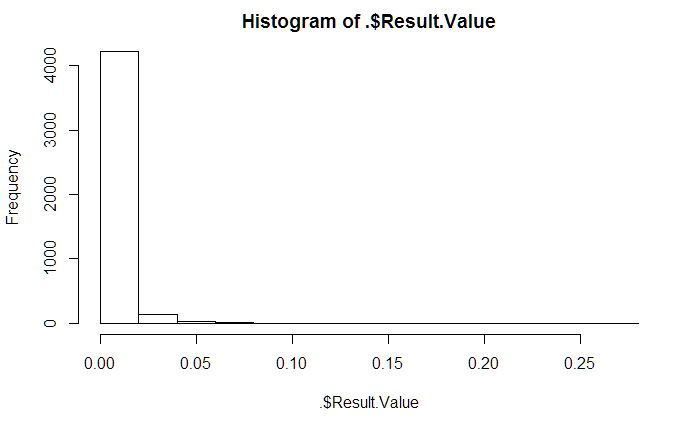

```r
#
CHL04_03 %>% filter(FILE != "CH03" & Units == "MG") %>%
{hist(.$Result.Value)}
```

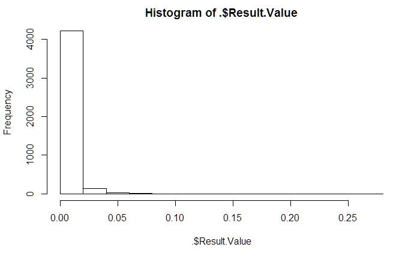

```r
CHL04_03 %>% filter(Units == "MG") %>%
    {hist(.$Result.Value)}
```

```r
CHL04_03 %>% filter(FILE != "CH03" & Units == "MG") %>% {summary(.$Result.Value)}
```

```
   Min. 1st Qu.  Median    Mean 3rd Qu.    Max.
0.00037 0.00131 0.00332 0.00504 0.00500 0.26700
```

```r
CHL04_03 %>% filter(FILE != "CH03" & Units == "ML") %>% {summary(.$Result.Value)}
```

```
   Min. 1st Qu.  Median    Mean 3rd Qu.    Max.
    100     250     250     382     500    3860
```

```r
CHL04_03 %>% filter(Units == "ML") %>% {summary(.$Result.Value)}
```

```
   Min. 1st Qu.  Median    Mean 3rd Qu.    Max.
    100     250     250     382     500    3860
```

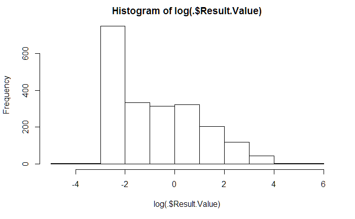

```r
# CHL04_03 %>% filter(Units == "UG" & is.na(Units.old)) %>% arrange(Result.Value)
# %>% {summary(.$Result.Value)}
CHL04_03 %>% filter(Units == "UG" & is.na(Units.old) & Result.Value > 0) %>%
{hist(log(.$Result.Value))}
```

```r
#
CHL04_03 %>% filter(Units == "UG"  & Result.Value > 0) %>%
{table(.$Units.old, .$FILE, useNA = "ifany")}
```

```
       CH01 CH02 CH03
  MG      0    0 3810
  UG      0    0 1489
  <NA>  161 1930    0
```

```r
CHL04_03 %>% filter(Units == "UG"  & Result.Value > 0) %>%
{table(.$Method.GRP, .$FILE, useNA = "ifany")}
```

```
           CH01 CH02 CH03
  CHL         0    0 3810
  CHL_hplc  161 1930 1489
```

- Patterns for Result Value conversion ::

```r
CHL04_03 %<>% mutate(
    RV2_ug = case_when(
        Units == "MG" & is.na(Units.old) ~ signif(Result.Value*1000, digits=5),
        Units.old == "MG" ~ signif(Result.Value*1000, digits=5),
        Units == "UG"  ~ signif(Result.Value, digits=5),
        TRUE ~ as.numeric(NA)),
    Units_X = case_when(
        Units %in% c("MG", "UG") ~ "UG",
        TRUE ~ as.character(NA))) %>%
    select(FILE:Result.Value, Units, RV2_ug, Units_X, everything())
```

7. Correct Dates

```r
select(CHL04_03, contains("Date", ignore.case = F)) %>% names(.) -> date_vars
# date_vars <- c( "Sample.Date","Date.Match","Sample.Received.Date","Analysis.Date")
#
CHL04_03 %<>% mutate_at(
    .vars = date_vars,
    .funs = funs(as.Date(., origin="1899-12-30")))
```

- Version datafile

```r
CHL04_04 <- CHL04_03
```

#### 1.62 Align Vars (3)

8. Re-Calc Sample.Keys (1,2, 6[?])
   - Push SKey6 to back

```r
# sum(is.na(CHL04_01$SKey2))
# max(nchar(CHL04_01$SKey1))
CHL04_04 %<>% mutate(
    SKey1 = paste(.$MLID_00,
                  as.numeric(trunc(.$Sample.Date) - as.Date("1899-12-30")),
                  sep="."),
    SKey2 = paste(.$MLID_00,
                  as.numeric(trunc(.$Sample.Date) - as.Date("1899-12-30")),
                  .$Sample.Number,
                  sep="."))
CHL04_04 %<>% select(-SKey6, -ACT.ID, everything())
```

**Remember that these Sample.Keys will need to be re-built after the SDate_x, MLID_x, and SNum_x values are extracted**

9. Integrate Comments
   - `Project.Comment` :: **REMOVE** (no info)
   - `Comment_02` :: Add to `Result.Comment` (only 1 value)
   - `Sample.Comment` :: Add to `Activity.Comment` (only 1 value)
   - `Test.Comment` :: Add to `Result.comment` (only 2 values)
   - `Note` :: left **as is**
   - `Comment` :: left **as is**
- Keep ::
  - `Activity.Comment`
  - `Comment`
  - `Result.Comment`
  - `Note`

```r
CHL04_04 %>% select(comments) %>% distinct() %>% as.data.frame(.) -> Comments_uniq
# openxlsx::write.xlsx(Comments_uniq, file="CHL_comments_190220.xlsx")
```

```r
CHL04_04 %<>% mutate(
    Result.Comment = case_when(
        !is.na(Test.Comment) & is.na(Result.Comment) ~ Test.Comment,
        !is.na(Test.Comment) & !is.na(Result.Comment) ~ paste(.$Result.Comment,
                                                              .$Test.Comment,
                                                              sep=". "),
        !is.na(Comment_02) & is.na(Result.Comment) ~ Comment_02,
        !is.na(Comment_02) & !is.na(Result.Comment) ~ paste(.$Result.Comment,
                                                            .$Comment_02,
                                                            sep=". "),
        !is.na(Result.Comment) ~ Result.Comment,
        is.na(Result.Comment) ~ as.character(NA)),
    Activity.Comment = case_when(
        !is.na(Sample.Comment) & is.na(Activity.Comment) ~ Sample.Comment,
        !is.na(Sample.Comment) & !is.na(Activity.Comment) ~ paste(.$Activity.Comment,
                                                                  .$Sample.Comment,
                                                                  sep=". "),
        !is.na(Activity.Comment) ~ Activity.Comment,
        is.na(Activity.Comment) ~ as.character(NA))) %>%
    select(-Comment_02, -Project.Comment, -Sample.Comment, -Test.Comment, everything())
```

#### 1.7 Version Datafile

```r
CHL05_01 <- CHL04_04
# openxlsx::write.xlsx(CHL05_01, file="CHL05_00_190221.xlsx")
```

## II: Metadata Cleanup

### 2.0 Identify Unique Records and Split-samples

#### 2.1 Boost Sample Key to account for parameters

- SKey3 :: MLID + SDate + SNum + ParamX

```r
CHL05_01 %<>% mutate(SKey3 = as.character(NA)) %>% mutate(
    SKey3 = paste(.$MLID_00,
                  as.numeric(trunc(.$Sample.Date) - as.Date("1899-12-30")),
                  .$Sample.Number,
                  .$ParamX,
                  sep=".")) %>%
    select(FILE:SKey2, SKey3,
           RECORD_status, RESENT_status, dupe_rec,
           everything())
table(CHL05_01$RECORD_status, useNA = "ifany")
```

```
    CHL_rerun   DROP_resent        IGNORE IGNORE_gslWET      KEEP_CHL          <NA>
         2368            55           144            48          2677          9115
```

- In order to find the split samples, need to make sure that any / all duplicate records are identified and accounted for…

#### 2.2 Find Duplicate Records

```r
CHL05_01 %>% {table(.$SKey3, useNA="ifany")} %>%
    as.data.frame(.) %>%
    {table(.$Freq)}
```

```
   1    2    3    4
5554 3757   57  292
```

```r
CHL05_01 %>% {table(.$SKey3, useNA="ifany")} %>%
    as.data.frame(.) %>%
    filter(.$Freq > 1) -> dupe_SK3
```

- Add Method.GRP to Keys as `SKey4`

```r
CHL05_01 %<>% mutate(SKey4 = as.character(NA)) %>% mutate(
    SKey4 = paste(.$MLID_00,
                  as.numeric(trunc(.$Sample.Date) - as.Date("1899-12-30")),
                  .$Sample.Number,
                  .$ParamX,
                  .$Method.GRP,
                  sep=".")) %>%
    select(-Batch.Number, -Test.Number, -MethPar.Key,
           -Sample.Matrix, everything()) %>%
    select(FILE:SKey3, SKey4, everything())
```

```r
CHL05_01 %>% {table(.$SKey4, useNA = "ifany")} %>%
    as.data.frame(.) %>%
    {table(.$Freq)}
```

```
   1    2    3
6134 4051   57
```

```r
CHL05_01 %>% {table(.$SKey4, useNA = "ifany")} %>%
    as.data.frame(.) %>%
    filter(.$Freq > 1) -> dupe_SK4
```

- After re-coding of ParamX, have found more sets of duplicated records (190221)
- REmove “*DIFF*” vars from DF, then re-calculate for SK4 dupes

```r
select(CHL05_01, contains("DIFF", ignore.case = T)) %>% names(.) -> DIFF_vars
#
CHL05_02 <- select(CHL05_01, -DIFF_vars)
```

```r
# keep order of SKey for matchup
dupe_SK4  %<>% arrange(Var1)
CHL05_02 %<>% arrange(SKey4)
#
CharDIFF <- data.frame(); NumDIFF <- data.frame()
#
for (j in dupe_SK4$Var1) {
    DUPE.j <- CHL05_02[CHL05_02$SKey4 == j,]
# numeric fields
    DIFF.rv <- ifelse(
                var(c(DUPE.j$Result.Value), na.rm=TRUE) > 0, "YES", "no")
    DIFF.sampnum <- ifelse(
                var(as.numeric(c(DUPE.j$Sample.Number)), na.rm=TRUE) > 0, "YES", "no")
    DIFF.samptype <- ifelse(
                var(c(DUPE.j$SType2), na.rm=TRUE) > 0, "YES", "no")
    DIFF.testnum <- ifelse(
                var(c(DUPE.j$Test.Number), na.rm=TRUE) > 0, "YES", "no")
    DIFF.lrl <- ifelse(
                var(c(DUPE.j$Lower.Report.Limit), na.rm=TRUE) > 0, "YES", "no")
    DIFF.mdl <- ifelse(
                var(c(DUPE.j$Method.Detect.Limit), na.rm=TRUE) > 0, "YES", "no")
    DIFF.VOL <- ifelse(
                var(c(DUPE.j$VOL_filt), na.rm=TRUE) > 0, "YES", "no")
    NumDIFF <- rbind(NumDIFF, data.frame(KEY.1 = j, DIFF.rv, DIFF.sampnum, DIFF.samptype, DIFF.testnum, DIFF.lrl, DIFF.mdl, DIFF.VOL))
    ## character fields
    for (k in 1:nrow(DUPE.j)) {
        DIFF.labfile <- ifelse(
            as.logical(setequal(DUPE.j$Lab.filename[k], DUPE.j$Lab.filename)),
            "no", "YES")
        DIFF.projnm <- ifelse(
            as.logical(setequal(DUPE.j$Project.Name[k], DUPE.j$Project.Name)),
            "no", "YES")
        DIFF.batchnum <- ifelse(
            as.logical(setequal(DUPE.j$Batch.Number[k], DUPE.j$Batch.Number)),
            "no", "YES")
        DIFF.anldate <- ifelse(
            as.logical(setequal(DUPE.j$Analysis.Date[k], DUPE.j$Analysis.Date)),
            "no", "YES")
        DIFF.FILE <- ifelse(
            as.logical(setequal(DUPE.j$FILE[k], DUPE.j$FILE)),
            "no", "YES")
        DIFF.METHid <- ifelse(
            as.logical(setequal(DUPE.j$Method.ID[k], DUPE.j$Method.ID)),
            "no", "YES")
        DIFF.METHgrp <- ifelse(
            as.logical(setequal(DUPE.j$Method.GRP[k], DUPE.j$Method.GRP)),
            "no", "YES")
        DIFF.ParamX <- ifelse(
            as.logical(setequal(DUPE.j$ParamX[k], DUPE.j$ParamX)),
            "no", "YES")
        CharDIFF <- rbind(CharDIFF, data.frame(KEY.1 = j, DIFF.labfile, DIFF.projnm, DIFF.batchnum, DIFF.anldate, DIFF.FILE, DIFF.METHid, DIFF.METHgrp, DIFF.ParamX)) }
    DIFFs <- merge(CharDIFF, NumDIFF)  }
## bring it all together
DIFFs %<>% distinct(.)
CHL05_compareDupes <- left_join(CHL05_02, distinct(DIFFs),
                                by = c("SKey4" = "KEY.1"))
```

```r
CHL05_compareDupes %<>% mutate(DIFF.all = as.character(NA)) %>% mutate(
    DIFF.all =
        paste(
            paste(.$DIFF.labfile,
                  .$DIFF.projnm,
                  .$DIFF.batchnum,
                  .$DIFF.anldate,
                  .$DIFF.FILE,
                  .$DIFF.METHid,
                  .$DIFF.METHgrp,
                  .$DIFF.ParamX, sep="."),
            paste(.$DIFF.rv,
                  .$DIFF.sampnum,
                  .$DIFF.samptype,
                  .$DIFF.testnum,
                  .$DIFF.lrl,
                  .$DIFF.mdl,
                  .$DIFF.VOL, sep="."), sep="_"))
##
CHL05_compareDupes %<>% mutate(
    DIFF.all = case_when(
        DIFF.all == "NA.NA.NA.NA.NA.NA.NA.NA_NA.NA.NA.NA.NA.NA.NA" ~ as.character(NA),
        !is.na(DIFF.all) ~ DIFF.all,
        is.na(DIFF.all) ~ as.character(NA))) %>%
    select(-DIFF.all, everything())
#
CHL05_compareDupes %>% distinct(DIFF.all) %>% nrow(.)-1
```

```
[1] 8
```

```r
# CHL05_compareDupes %>% distinct(DIFF.all) %>% arrange(DIFF.all)
CHL05_compareDupes %>% {addmargins(table(.$DIFF.all, !is.na(.$FILE), useNA = "ifany"),1)}
```

```
                                                  TRUE
  no.no.no.no.no.no.no.no_no.no.NA.YES.NA.NA.NA      2
  no.no.no.no.YES.no.no.no_no.no.NA.no.no.no.NA   7164
  no.no.no.no.YES.no.no.no_no.no.NA.no.no.no.no     18
  no.no.no.no.YES.YES.no.no_no.no.NA.no.no.no.NA   908
  YES.no.no.no.no.no.no.no_no.no.NA.no.no.no.NA      8
  YES.no.no.no.no.YES.no.no_no.no.NA.no.NA.NA.NA    12
  YES.no.no.no.no.YES.no.no_no.no.NA.no.no.no.NA     8
  YES.no.no.no.YES.no.no.no_no.no.NA.no.no.no.NA   153
  <NA>                                            6134
  Sum                                            14407
```

```r
# openxlsx::write.xlsx(CHL05_compareDupes, file="CHL05_DupeCompare_190221.xlsx")
```

- Boost `dupe_SK4` w/ dupe-info

```r
for (j in dupe_SK4$Var1) {
    dupe_SK4$DIFF.all[dupe_SK4$Var1 == j] <- unique(CHL05_compareDupes$DIFF.all[CHL05_compareDupes$SKey4 == j])
}
#
dupe_sk4.rep3 <- dupe_SK4 %>% filter(Freq > 2)
#
dupe_sk4.rep3 %>% distinct(DIFF.all)
```

| DIFF.all |
| --- |
| YES.no.no.no.YES.no.no.no_no.no.NA.no.no.no.NA |
| no.no.no.no.YES.no.no.no_no.no.NA.no.no.no.no |

- [190221; pm] Working out new set of Dupe_SK4 issues…

#### 2.3 Fix Duplicate Records

- Working dataframe is now `CHL05_compareDupes`
- Label duplicate records

```r
CHL05_compareDupes %<>% mutate(
    dupe_rec = case_when(
        SKey4 %in% dupe_SK4$Var1 ~ "dupe",
        TRUE ~ as.character(NA)))
```

- Fix Set [1] :: `no.no.no.no.no.no.no.no_no.no.NA.YES.NA.NA.NA`

```r
CHL05_compareDupes %<>% mutate(
    RESENT_status = case_when(
        DIFF.all == "no.no.no.no.no.no.no.no_no.no.NA.YES.NA.NA.NA" &
            dupe_rec == "dupe" & Test.Number == "10256328" ~ "drop_TestN",
        !is.na(RESENT_status) ~ RESENT_status,
        is.na(RESENT_status) ~ as.character(NA)))
# CHL05_compareDupes %>%
#     filter(DIFF.all == "no.no.no.no.no.no.no.no_no.no.NA.YES.NA.NA.NA")
```

```r
CHL05_compareDupes %<>% mutate(
    RESENT_status = case_when(
        DIFF.all %in% c("no.no.no.no.YES.no.no.no_no.no.NA.no.no.no.NA",
                        "no.no.no.no.YES.no.no.no_no.no.NA.no.no.no.no") &
            FILE == "CH03" &
            SKey4 %in% dupe_sk4.rep3$Var1[dupe_sk4.rep3$Freq > 2] &
            (is.na(PROJECT.x) | PROJECT.x != PROJECT.y) ~ "drop_proj",
        DIFF.all %in% c("no.no.no.no.YES.no.no.no_no.no.NA.no.no.no.NA",
                        "no.no.no.no.YES.no.no.no_no.no.NA.no.no.no.no") &
            FILE != "CH03" &
            SKey4 %in% dupe_sk4.rep3$Var1[dupe_sk4.rep3$Freq > 2] &
            (is.na(PROJECT.x)) ~ "drop_proj",
        DIFF.all %in% c("no.no.no.no.YES.no.no.no_no.no.NA.no.no.no.NA",
                        "no.no.no.no.YES.no.no.no_no.no.NA.no.no.no.no") &
            FILE != "CH03" &
            (!SKey4 %in% dupe_sk4.rep3$Var1[dupe_sk4.rep3$Freq > 2]) ~ "drop_proj",
        !is.na(RESENT_status) ~ RESENT_status,
        is.na(RESENT_status) ~ as.character(NA)))
```

- Fix Set [4] :: `no.no.no.no.YES.YES.no.no_no.no.NA.no.no.no.NA`

```r
CHL05_compareDupes %<>% mutate(
    RESENT_status = case_when(
        DIFF.all == "no.no.no.no.YES.YES.no.no_no.no.NA.no.no.no.NA" &
            is.na(VOL_filt) ~ "drop_grp",
        !is.na(RESENT_status) ~ RESENT_status,
        is.na(RESENT_status) ~ as.character(NA)))
```

- **Note** :: Will Need to *ignore* `RECORD_status` for these duplicated records, and rely on `RESENT_status` instead
- Fix Set [5] :: `YES.no.no.no.no.no.no.no_no.no.NA.no.no.no.NA`

```r
CHL05_compareDupes %<>% mutate(
    RESENT_status = case_when(
        DIFF.all == "YES.no.no.no.no.no.no.no_no.no.NA.no.no.no.NA" &
            Lab.filename == "UDWQ_EDD_20170816.txt" ~ "drop_LabF",
        !is.na(RESENT_status) ~ RESENT_status,
        is.na(RESENT_status) ~ as.character(NA)))
```

- Fix Set [6,7] :: `YES.no.no.no.no.YES.no.no_no.no.NA.no.NA.NA.NA` *OR* `YES.no.no.no.no.YES.no.no_no.no.NA.no.no.no.NA`

```r
CHL05_compareDupes %<>% mutate(
    RESENT_status = case_when(
        DIFF.all %in% c("YES.no.no.no.no.YES.no.no_no.no.NA.no.NA.NA.NA",
                        "YES.no.no.no.no.YES.no.no_no.no.NA.no.no.no.NA") &
            Method.ID == "HPLC" ~ "drop_LabF",
        !is.na(RESENT_status) ~ RESENT_status,
        is.na(RESENT_status) ~ as.character(NA)))
```

- Fix Set [8] :: `YES.no.no.no.YES.no.no.no_no.no.NA.no.no.no.NA`

```r
CHL05_compareDupes %<>% mutate(
    RESENT_status = case_when(
        DIFF.all == "YES.no.no.no.YES.no.no.no_no.no.NA.no.no.no.NA" &
        SKey4 %in% dupe_sk4.rep3$Var1[dupe_sk4.rep3$Freq > 2] &
        FILE != "CH03" ~ "drop_labF",
        !is.na(RESENT_status) ~ RESENT_status,
        is.na(RESENT_status) ~ as.character(NA)))
```

- Summary of Duplicated Records

```r
CHL05_compareDupes %>% filter(!is.na(dupe_rec)) %>%
    {addmargins(table(.$DIFF.all, .$RESENT_status, useNA="ifany"))} %>%
    htmlTable::htmlTable(.,
                         css.cell = rbind(rep("padding-left: 0.8em; padding-right: 0.8em;font-size: 0.75em;",times=ncol(.)+1), matrix("padding-left: 0.75em; padding-right: 0.75em; font-size: 0.75em;", ncol=ncol(.)+1, nrow=nrow(.))))
```

|  | drop_grp | drop_labF | drop_LabF | drop_proj | drop_TestN |  | Sum |
| --- | --- | --- | --- | --- | --- | --- | --- |
| no.no.no.no.no.no.no.no_no.no.NA.YES.NA.NA.NA | 0 | 0 | 0 | 0 | 1 | 1 | 2 |
| no.no.no.no.YES.no.no.no_no.no.NA.no.no.no.NA | 0 | 0 | 0 | 3582 | 0 | 3582 | 7164 |
| no.no.no.no.YES.no.no.no_no.no.NA.no.no.no.no | 0 | 0 | 0 | 12 | 0 | 6 | 18 |
| no.no.no.no.YES.YES.no.no_no.no.NA.no.no.no.NA | 454 | 0 | 0 | 0 | 0 | 454 | 908 |
| YES.no.no.no.no.no.no.no_no.no.NA.no.no.no.NA | 0 | 0 | 4 | 0 | 0 | 4 | 8 |
| YES.no.no.no.no.YES.no.no_no.no.NA.no.NA.NA.NA | 0 | 0 | 6 | 0 | 0 | 6 | 12 |
| YES.no.no.no.no.YES.no.no_no.no.NA.no.no.no.NA | 0 | 0 | 4 | 0 | 0 | 4 | 8 |
| YES.no.no.no.YES.no.no.no_no.no.NA.no.no.no.NA | 0 | 102 | 0 | 0 | 0 | 51 | 153 |
| Sum | 454 | 102 | 14 | 3594 | 1 | 4108 | 8273 |

#### 2.4 Version dataframe after duplicate records accounted for

- Working dataset has ::
  - **RESENT_status == *NULL***

```r
CHL06_01 <- CHL05_compareDupes
# openxlsx::write.xlsx(CHL06_01, file="CHL06_00_190222.xlsx")
```

- Duplicates found and fixed; 190222

### 3.0 Cleanup Split-Sample metadata and results

#### 3.1 Integrate first and second CHL-method analyses

UPHL-LIMS has a limitation on running a sample under two methods for the same analyte, apparently they must be re-enterred in to the LIMS, such that the result from the second analysis has incorrect (inaccurate) MLID, SDate information, and the Sample.Numbers must be matched up to the original sample record

```r
CHL06_01 %>%
    filter(is.na(RESENT_status)) %>%
    {addmargins(table(.$SKey1, .$Method.GRP,useNA="ifany"),1)} %>%
    as.data.frame.matrix(.) %>%
    tibble::rownames_to_column(., var="SKey1") -> SK1_MethGrps
#
SK1_MethGrps %<>% mutate(
    Meth_sets = case_when(
        CHL > 0 & CHL_hplc > 0 ~ "Both",
        TRUE ~ as.character(NA)
    )
)
SK1_MethGrps %>% {table(.$Meth_sets, useNA="ifany")}
```

```
Both <NA>
 296 1408
```

- [190221] : Need to go back to Parameter conversions, redo, then proceed w/ better ParamX x Param.Description alignment (Sect. 1.6 #5)
  - Completed [190222]
- Sets that include Field/Equip Blanks need a closer look…

#### 3.2 Identify Re-sampled CHL records and assign correct sample-collection-metadata

- *Review prior CHL-resample matchup script and replicate here…*

```r
CHL06_01 %>%
    filter(is.na(RESENT_status)) %>%
    filter(!grepl("[[:digit:]]", .$MLID_00)) -> NoMLID_ch6
NoMLID_ch6 %<>% select(MLID_00, Sample.Date, Sample.Time, Sample.Number,
                       Sample.Description, SampDesc, SNum_x,
                       Analysis.Date, Method.ID:Method.GRP, ParamX,
                       Batch.Number, Test.Number)
# NoMLID_ch6 %>% {sort(unique(.$Sample.Description))}
class(NoMLID_ch6$SampDesc)
```

```
[1] "character"
```

```r
CHL06_01 %<>% select(-FILE, -Lab.filename, everything()) %>%
    select(Sample.Description, everything())
```

- 2nd Set CHL-records have non-integer `MLID_00` [*this needs cleanup*]

```r
CHL06_01 %>%
    filter(is.na(RESENT_status)) %>%
    filter(!grepl("[[:digit:]]", .$MLID_00)) %>%
    {addmargins(table(.$MLID_00, .$Method.GRP,useNA="ifany"))}
```

```
            CHL CHL_hplc  Sum
  CHL_samp    0     2367 2367
  CHL_test    0      324  324
  missing    18        0   18
  NoMLID      0       40   40
  Sum        18     2731 2749
```

- `MLID_00` == “*missing*” [18 records]
  - 4 sites; 2 w/ extractable MLIDs and 2 w/ OTLK-related *presumed* MLIDs

```r
CHL06_01 %<>% mutate(
    MLID_00 = case_when(
        MLID_00 == "missing" &
            Trip_root == "UCASE" ~ substr(.$Sample.Description,1,7),
        MLID_00 == "missing" &
            Sample.Description == "PROVO RIVER DELTA RESTORATION" ~ "4917343",
         MLID_00 == "missing" &
            Sample.Description == "LINDON DRAIN" ~ "4995120",
        !is.na(MLID_00) ~ MLID_00,
        is.na(MLID_00) ~ as.character(NA)
        ))
```

- `MLID_00` == “NoMLID”
  - DWQ-USGS collaborative project on San juan / Colorado R. / Lake Powell

```r
CHL06_01 %<>% mutate(
    MLID_00 = case_when(
        MLID_00 == "NoMLID" ~ paste("USGS",
                                    .$Sample.Description,
                                    sep=""),
        !is.na(MLID_00) ~ MLID_00,
        is.na(MLID_00) ~ as.character(NA)
        ))
# CHL06_01 %>% filter(MLID_00 == "NoMLID")
```

- `MLID_00` ~ “CHL_$” {CHL_samp; CHL_test}
  - These records have a Sample.Number in the Sample.Description field
- Use `SNum_x` as the *Integrated* Sample.Number field
  - For the `CHL_...` samples, the value in the Sample.Description goes into `SNum_x`

```r
CHL06_01 %<>% mutate(
    SNum_x = case_when(
        is.na(RESENT_status) &
            grepl("CHL_", .$MLID_00) ~ Sample.Description,
        !is.na(SNum_x) ~ SNum_x,
        is.na(SNum_x) ~ as.character(NA)
        ))
```

#### 3.3 Extract Parent-metadata usiung `SNum_x`

- Records where a Sample.Number is provided in the `Sample.Description` field need to have MLID, Sample.Date, Sample.Time, Sample.Number, and TripID updated based on the parent ID
- Formatting

```r
select(CHL06_01, contains("_x", ignore.case = T)) %>% names(.)
```

```
[1] "SDate_x"  "SNum_x"   "Units_X"  "TripID_x" "MLID_x"   "Method_x"
```

```r
#
CHL06_01 %<>% select(Sample.Description:Trip.ID, TripID_x,
                     Sample.Date, SDate_x,Sample.Time,
                     MLID_00, MLID_x,
                     Sample.Number, SNum_x,
                     Method.ID, Method.GRP,
                     Analysis.Date, ParamX, Benthic, VOL_filt,
                     everything())
```

- When `Sample.Description` $<$ “*2199999*”, and SNum_x is *NULL*, then apply that value to SNum_x

```r
# CHL06_01 -> CHL06_01_copy
CHL06_01 %<>% mutate(SNum_x = as.character(NA)) %>% mutate(
    SNum_x = case_when(
        (!is.na(Sample.Description) &
             Sample.Description < "2199999") ~ Sample.Description,
        !is.na(SNum_x) ~ SNum_x,
        is.na(SNum_x) ~ as.character(NA)
        ))
```

- When SNum_x != *NULL*, apply parent info to 2nd-record

```r
CHL_2nd <- CHL06_01 %>%
    filter(is.na(RESENT_status)) %>%
    filter(!is.na(Sample.Description) & Sample.Description < "2199999") %>%
    select(Sample.Description, Sample.Number, MLID_00) %>% distinct(.)
CHL_parent <- CHL06_01 %>%
    filter(is.na(RESENT_status)) %>%
    filter(is.na(Sample.Description) | !Sample.Description < "2199999") %>%
    select(Sample.Date, Sample.Number, MLID_00,
           Trip_root, Method.ID) %>% distinct(.)
# setdiff(CHL_2nd_oo, CHL_2nd)
# length(unique(CHL_parent$MLID_00))
length(unique(CHL06_01$SNum_x))
```

```
[1] 655
```

```r
for (j in unique(CHL06_01$SNum_x[!is.na(CHL06_01$SNum_x)])) {
    CHL06_01$MLID_x[!is.na(CHL06_01$SNum_x) & CHL06_01$SNum_x == j] <-
        unique(CHL06_01$MLID_00[CHL06_01$Sample.Number == j])
    CHL06_01$SDate_x[!is.na(CHL06_01$SNum_x) & CHL06_01$SNum_x == j] <-
        unique(CHL06_01$Sample.Date[CHL06_01$Sample.Number == j])
    CHL06_01$TripID_x[!is.na(CHL06_01$SNum_x) & CHL06_01$SNum_x == j] <-
        unique(CHL06_01$Trip.ID[CHL06_01$Sample.Number == j])
    CHL06_01$Trip_root[!is.na(CHL06_01$SNum_x) & CHL06_01$SNum_x == j] <-
        unique(CHL06_01$Trip_root[CHL06_01$Sample.Number == j])
}
```

[output not shown]

```r
# for (j in unique(CHL06_01$SNum_x[!is.na(CHL06_01$SNum_x)])) {
#     CHL06_01$MLID_x[!is.na(CHL06_01$SNum_x) & CHL06_01$SNum_x == j] <-
#         paste(unique(CHL06_01$MLID_00[CHL06_01$Sample.Number == j]), sep="/")
#     CHL06_01$SDate_x[!is.na(CHL06_01$SNum_x) & CHL06_01$SNum_x == j] <-
#         paste(unique(CHL06_01$Sample.Date[CHL06_01$Sample.Number == j]), sep="/")
#     CHL06_01$TripID_x[!is.na(CHL06_01$SNum_x) & CHL06_01$SNum_x == j] <-
#         paste(unique(CHL06_01$Trip.ID[CHL06_01$Sample.Number == j]), sep="/")
#     CHL06_01$Trip_root[!is.na(CHL06_01$SNum_x) & CHL06_01$SNum_x == j] <-
#         paste(unique(CHL06_01$Trip_root[CHL06_01$Sample.Number == j]), sep="/")
# }
# CHL06_01 %>% filter(
#     is.na(RESENT_status) &
#             (!is.na(Sample.Description) & Sample.Description < "2199999"))
# CHL06_01 %>% {table(.$TripID_x, useNA="ifany")} %>%
#     as.data.frame(.) %>%
#     {table(.$Freq)}
# length(unique(CHL06_01$TripID_x))
# nchar("UTAHLAKE091117")
# max(nchar(CHL06_01$SNum_x), na.rm=T)
# max(nchar(CHL06_01$SDate_x), na.rm=T)
# max(nchar(CHL06_01$TripID_x), na.rm=T)
# max(nchar(CHL06_01$Trip_root), na.rm=T)
# max(nchar(CHL06_01$SNum_x), na.rm=T)
```

- Patch holes in SDate_x, MLID_x, and SNum_x among records

```r
nrow(CHL06_01)
```

```
[1] 14407
```

```r
sum(is.na(CHL06_01$Sample.Date))
```

```
[1] 0
```

```r
sum(is.na(CHL06_01$SDate_x))
```

```
[1] 6401
```

```r
sum(is.na(CHL06_01$MLID_00))
```

```
[1] 0
```

```r
sum(is.na(CHL06_01$MLID_x))
```

```
[1] 6401
```

```r
sum(is.na(CHL06_01$Sample.Number))
```

```
[1] 0
```

```r
sum(is.na(CHL06_01$SNum_x))
```

```
[1] 10689
```

```r
CHL06_01 %>% filter(!is.na(Sample.Description) & is.na(SDate_x)) %>% nrow(.)
```

```
[1] 253
```

```r
# CHL06_01 %>% filter(!is.na(Sample.Description) & is.na(SDate_x))
```

**Version datafile**

```r
# CHL06_02 <- CHL06_01
```

- Fill gaps for CHL-records (after 2nd-record cleanup)

```r
CHL06_02 %<>% mutate(
    SDate_x = case_when(
        is.na(SDate_x) ~ Sample.Date,
        !is.na(SDate_x) ~ SDate_x),
    MLID_x = case_when(
        is.na(MLID_x) ~ MLID_00,
        !is.na(MLID_x) ~ MLID_x),
    SNum_x = case_when(
        is.na(SNum_x) ~ as.character(Sample.Number),
        !is.na(SNum_x) ~ SNum_x))
```

**Export File**

```r
# openxlsx::write.xlsx(CHL06_02, file="201718_CHL06_v02_11_190222.xlsx")
```

#### 3.4 Re-calculate Sample Keys

- First, organize fields into sensible pattern

```r
CHL06_03 <- CHL06_02 %>%
    select(-Sample.Description, -TripID_x, -Method_x, -QC_type, -Param.Description,
           -SType2, -Units.old, everything()) %>%
    select(-contains("DIFF", ignore.case = )) %>%
    select(FILE, Lab.filename, Project.Name, Sample.Received.Date,
           Trip_root, Trip.ID, Sample.Date:VOL_filt, everything())
```

**Sample Keys based on updated [corrected] Sample-metadata**

```r
CHL06_03 %<>% mutate(
    SKey1 = paste(.$MLID_x,
                  as.numeric(trunc(.$SDate_x) - as.Date("1899-12-30")),
                  sep="."),
    SKey2 = paste(.$MLID_x,
                  as.numeric(trunc(.$SDate_x) - as.Date("1899-12-30")),
                  .$SNum_x,
                  sep="."),
    SKey3 = paste(.$MLID_x,
                  as.numeric(trunc(.$SDate_x) - as.Date("1899-12-30")),
                  .$SNum_x,
                  .$ParamX,
                  sep="."),
    SKey4 = paste(.$MLID_x,
                  as.numeric(trunc(.$SDate_x) - as.Date("1899-12-30")),
                  .$SNum_x,
                  .$ParamX,
                  .$Method.GRP,
                  sep="."))
```

```r
CHL06_03 %>% {table(.$SKey4, useNA = "ifany")} %>%
    as.data.frame(.) %>% {table(.$Freq, useNA="ifany", deparse.level = 2)}
```

```
.$Freq
   1    2    3
4106 5059   61
```

```r
#
CHL06_03 %>% {table(.$SKey4, useNA = "ifany")} %>%
    as.data.frame(.) %>%
    filter(.$Freq > 1) -> dupe_SK4.x
##
CHL06_03 %>% filter(is.na(RESENT_status)) %>% {table(.$SKey4, useNA = "ifany")} %>%
    as.data.frame(.) %>% {table(.$Freq, useNA="ifany", deparse.level = 2)}
```

```
.$Freq
   1    2
8210 1016
```

```r
#
CHL06_03 %>% filter(is.na(RESENT_status)) %>%
    {table(.$SKey4, useNA = "ifany")} %>%
    as.data.frame(.) %>%
    filter(.$Freq > 1) -> dupe_SK4.x2
```

- Even though Dupe-records have already been evaluated, the changes made to MLID, SDate and SNumx could increase or decrease the frequency of those dupes. As such, the duplicate-record examination and correction procedures should be repeated here

#### 3.5 Repeat Duplicate-Record exmaination

```r
# Assign datafiles to working objects
CHL06_03 -> data_file
dupe_SK4.x -> dupe_key
# keep order of SKey for matchup
dupe_key  %<>% arrange(Var1)
data_file %<>% arrange(SKey4)
#
CharDIFF <- data.frame(); NumDIFF <- data.frame()
#
for (j in dupe_key$Var1) {
    DUPE.j <- data_file[data_file$SKey4 == j,]
# numeric fields
    DIFF.rv <- ifelse(
                var(c(DUPE.j$Result.Value), na.rm=TRUE) > 0, "YES", "no")
    DIFF.sampnum <- ifelse(
                var(as.numeric(c(DUPE.j$Sample.Number)), na.rm=TRUE) > 0, "YES", "no")
    DIFF.samptype <- ifelse(
                var(c(DUPE.j$SType2), na.rm=TRUE) > 0, "YES", "no")
    DIFF.testnum <- ifelse(
                var(c(DUPE.j$Test.Number), na.rm=TRUE) > 0, "YES", "no")
    DIFF.lrl <- ifelse(
                var(c(DUPE.j$Lower.Report.Limit), na.rm=TRUE) > 0, "YES", "no")
    DIFF.mdl <- ifelse(
                var(c(DUPE.j$Method.Detect.Limit), na.rm=TRUE) > 0, "YES", "no")
    DIFF.VOL <- ifelse(
                var(c(DUPE.j$VOL_filt), na.rm=TRUE) > 0, "YES", "no")
    NumDIFF <- rbind(NumDIFF, data.frame(KEY.1 = j, DIFF.rv, DIFF.sampnum, DIFF.samptype, DIFF.testnum, DIFF.lrl, DIFF.mdl, DIFF.VOL))
    ## character fields
    for (k in 1:nrow(DUPE.j)) {
        DIFF.labfile <- ifelse(
            as.logical(setequal(DUPE.j$Lab.filename[k], DUPE.j$Lab.filename)),
            "no", "YES")
        DIFF.projnm <- ifelse(
            as.logical(setequal(DUPE.j$Project.Name[k], DUPE.j$Project.Name)),
            "no", "YES")
        DIFF.batchnum <- ifelse(
            as.logical(setequal(DUPE.j$Batch.Number[k], DUPE.j$Batch.Number)),
            "no", "YES")
        DIFF.anldate <- ifelse(
            as.logical(setequal(DUPE.j$Analysis.Date[k], DUPE.j$Analysis.Date)),
            "no", "YES")
        DIFF.FILE <- ifelse(
            as.logical(setequal(DUPE.j$FILE[k], DUPE.j$FILE)),
            "no", "YES")
        DIFF.METHid <- ifelse(
            as.logical(setequal(DUPE.j$Method.ID[k], DUPE.j$Method.ID)),
            "no", "YES")
        DIFF.METHgrp <- ifelse(
            as.logical(setequal(DUPE.j$Method.GRP[k], DUPE.j$Method.GRP)),
            "no", "YES")
        DIFF.ParamX <- ifelse(
            as.logical(setequal(DUPE.j$ParamX[k], DUPE.j$ParamX)),
            "no", "YES")
        CharDIFF <- rbind(CharDIFF, data.frame(KEY.1 = j, DIFF.labfile, DIFF.projnm, DIFF.batchnum, DIFF.anldate, DIFF.FILE, DIFF.METHid, DIFF.METHgrp, DIFF.ParamX)) }
    DIFFs <- merge(CharDIFF, NumDIFF)  }
## bring it all together
DIFFs %<>% distinct(.)
CHL06_compDupes <- left_join(data_file, distinct(DIFFs),
                                by = c("SKey4" = "KEY.1"))
```

```r
CHL06_compDupes %<>% mutate(DIFF.all = as.character(NA)) %>% mutate(
    DIFF.all =
        paste(
            paste(.$DIFF.labfile,
                  .$DIFF.projnm,
                  .$DIFF.batchnum,
                  .$DIFF.anldate,
                  .$DIFF.FILE,
                  .$DIFF.METHid,
                  .$DIFF.METHgrp,
                  .$DIFF.ParamX, sep="."),
            paste(.$DIFF.rv,
                  .$DIFF.sampnum,
                  .$DIFF.samptype,
                  .$DIFF.testnum,
                  .$DIFF.lrl,
                  .$DIFF.mdl,
                  .$DIFF.VOL, sep="."), sep="_"))
##
CHL06_compDupes %<>% mutate(
    DIFF.all = case_when(
        DIFF.all == "NA.NA.NA.NA.NA.NA.NA.NA_NA.NA.NA.NA.NA.NA.NA" ~ as.character(NA),
        !is.na(DIFF.all) ~ DIFF.all,
        is.na(DIFF.all) ~ as.character(NA))) %>%
    select(-DIFF.all, everything())
#
CHL06_compDupes %>% distinct(DIFF.all) %>% nrow(.)-1
```

```
[1] 8
```

```r
# CHL06_compDupes %>% distinct(DIFF.all) %>% arrange(DIFF.all)
CHL06_compDupes %>% {addmargins(table(.$DIFF.all, !is.na(.$FILE), useNA = "ifany"),1)}
```

```
                                                   TRUE
  no.no.no.no.no.no.no.no_no.no.NA.YES.NA.NA.NA       2
  no.no.no.no.YES.no.no.no_no.no.NA.no.no.no.NA    7432
  no.no.no.no.YES.no.no.no_no.no.NA.no.no.no.no      18
  no.no.no.no.YES.YES.no.no_no.no.NA.no.no.no.NA   2664
  YES.no.no.no.no.no.no.no_no.no.NA.no.no.no.NA       8
  YES.no.no.no.no.YES.no.no_no.no.NA.no.NA.NA.NA     12
  YES.no.no.no.YES.no.no.no_no.no.NA.no.no.no.NA    153
  YES.no.no.no.YES.YES.no.no_no.no.NA.no.no.no.NA    12
  <NA>                                             4106
  Sum                                             14407
```

```r
# openxlsx::write.xlsx(CHL06_compDupes, file="CHL06_DupeCompare_190222.xlsx")
```

- Boost `dupe_SK4` w/ dupe-info

```r
for (j in dupe_SK4.x$Var1) {
    dupe_SK4.x$DIFF.all[dupe_SK4.x$Var1 == j] <- unique(CHL06_compDupes$DIFF.all[CHL06_compDupes$SKey4 == j])
}
#
dupe_sk4x.rep3 <- dupe_SK4.x %>% filter(Freq > 2)
#
dupe_sk4x.rep3 %>% {table(.$DIFF.all, .$Freq, useNA="ifany")}
```

```
                                                   3
  no.no.no.no.YES.no.no.no_no.no.NA.no.no.no.no    6
  YES.no.no.no.YES.no.no.no_no.no.NA.no.no.no.NA  51
  YES.no.no.no.YES.YES.no.no_no.no.NA.no.no.no.NA  4
```

#### 3.6 Fix Duplicated Records (*again*)

- Working dataframe is now `CHL06_compDupes`
- Label duplicate records

```r
CHL06_compDupes %<>% mutate(
    dupe_rec = case_when(
        SKey4 %in% dupe_SK4.x$Var1 ~ "dupe",
        TRUE ~ as.character(NA)))
```

- Fix Set [1] :: `no.no.no.no.no.no.no.no_no.no.NA.YES.NA.NA.NA`
  - Records already corrected

```r
# CHL06_compDupes %<>% mutate(
#     RESENT_status = case_when(
#         DIFF.all == "no.no.no.no.no.no.no.no_no.no.NA.YES.NA.NA.NA" &
#             dupe_rec == "dupe" & Test.Number == "10256328" ~ "drop_TestN",
#         !is.na(RESENT_status) ~ RESENT_status,
#         is.na(RESENT_status) ~ as.character(NA)))
```

- Fix Set [2+3] :: `no.no.no.no.YES.no.no.no_no.no.NA.no.no.no.NA` *OR* `no.no.no.no.YES.no.no.no_no.no.NA.no.no.no.no`
  - Triplicates in this set (6) have already been corrected

```r
CHL06_compDupes %<>% mutate(
    RESENT_status = case_when(
        DIFF.all %in% c("no.no.no.no.YES.no.no.no_no.no.NA.no.no.no.NA",
                        "no.no.no.no.YES.no.no.no_no.no.NA.no.no.no.no") &
            FILE == "CH03" &
            SKey4 %in% dupe_SK4.x$Var1[dupe_SK4.x$Freq > 2] &
            (is.na(PROJECT.x) | PROJECT.x != PROJECT.y) ~ "drop_proj",
        DIFF.all %in% c("no.no.no.no.YES.no.no.no_no.no.NA.no.no.no.NA",
                        "no.no.no.no.YES.no.no.no_no.no.NA.no.no.no.no") &
            FILE != "CH03" &
            SKey4 %in% dupe_SK4.x$Var1[dupe_SK4.x$Freq > 2] &
            (is.na(PROJECT.x)) ~ "drop_proj",
        DIFF.all %in% c("no.no.no.no.YES.no.no.no_no.no.NA.no.no.no.NA",
                        "no.no.no.no.YES.no.no.no_no.no.NA.no.no.no.no") &
            FILE != "CH03" &
            (!SKey4 %in% dupe_SK4.x$Var1[dupe_SK4.x$Freq > 2]) ~ "drop_proj",
        !is.na(RESENT_status) ~ RESENT_status,
        is.na(RESENT_status) ~ as.character(NA)))
# CHL06_compDupes %>%
#      filter(DIFF.all %in% c("no.no.no.no.YES.no.no.no_no.no.NA.no.no.no.NA",
#                         "no.no.no.no.YES.no.no.no_no.no.NA.no.no.no.no") &
#             FILE != "CH03" &
#             (!SKey4 %in% dupe_SK4.x$Var1[dupe_SK4.x$Freq > 2]))
```

- Fix Set [4] :: `no.no.no.no.YES.YES.no.no_no.no.NA.no.no.no.NA`

```r
CHL06_compDupes %<>% mutate(
    RESENT_status = case_when(
        DIFF.all == "no.no.no.no.YES.YES.no.no_no.no.NA.no.no.no.NA" &
            FILE != "CH03" ~ "drop_grp",
        !is.na(RESENT_status) ~ RESENT_status,
        is.na(RESENT_status) ~ as.character(NA)))
# CHL06_compDupes %>%
#     filter(DIFF.all == "no.no.no.no.YES.YES.no.no_no.no.NA.no.no.no.NA" &
#                !is.na(VOL_filt))
```

- Fix Set [5] :: `YES.no.no.no.no.no.no.no_no.no.NA.no.no.no.NA`
  - Already corrected

```r
# CHL06_compDupes %<>% mutate(
#     RESENT_status = case_when(
#         DIFF.all == "YES.no.no.no.no.no.no.no_no.no.NA.no.no.no.NA" &
#             Lab.filename == "UDWQ_EDD_20170816.txt" ~ "drop_LabF",
#         !is.na(RESENT_status) ~ RESENT_status,
#         is.na(RESENT_status) ~ as.character(NA)))
```

- Fix Set [6] :: `YES.no.no.no.no.YES.no.no_no.no.NA.no.NA.NA.NA`
  - Already corrected

```r
# CHL06_compDupes %<>% mutate(
#     RESENT_status = case_when(
#         DIFF.all == "YES.no.no.no.no.YES.no.no_no.no.NA.no.NA.NA.NA" &
#             Method.ID == "HPLC" ~ "drop_LabF",
#         !is.na(RESENT_status) ~ RESENT_status,
#         is.na(RESENT_status) ~ as.character(NA)))
```

- Fix Set [7] :: `YES.no.no.no.YES.no.no.no_no.no.NA.no.no.no.NA`
  - Already corrected

```r
# CHL06_compDupes %<>% mutate(
#     RESENT_status = case_when(
#         DIFF.all == "YES.no.no.no.YES.no.no.no_no.no.NA.no.no.no.NA" &
#             FILE != "CH03" ~ "drop_LabF",
#         !is.na(RESENT_status) ~ RESENT_status,
#         is.na(RESENT_status) ~ as.character(NA)))
```

- Fix Set [8] :: `YES.no.no.no.YES.YES.no.no_no.no.NA.no.no.no.NA`
  - All triples

```r
CHL06_compDupes %<>% mutate(
    RESENT_status = case_when(
        DIFF.all == "YES.no.no.no.YES.YES.no.no_no.no.NA.no.no.no.NA" &
        FILE != "CH03" ~ "drop_labF",
        !is.na(RESENT_status) ~ RESENT_status,
        is.na(RESENT_status) ~ as.character(NA)))
```

- Summary of Duplicated Records

```r
CHL06_compDupes %>% filter(!is.na(dupe_rec)) %>%
    {addmargins(table(.$DIFF.all, .$RESENT_status, useNA="ifany"))} %>%
    htmlTable::htmlTable(.,
                         css.cell = rbind(rep("padding-left: 0.8em; padding-right: 0.8em;font-size: 0.75em;",times=ncol(.)+1), matrix("padding-left: 0.75em; padding-right: 0.75em; font-size: 0.75em;", ncol=ncol(.)+1, nrow=nrow(.))))
```

|  | drop_grp | drop_labF | drop_LabF | drop_proj | drop_TestN |  | Sum |
| --- | --- | --- | --- | --- | --- | --- | --- |
| no.no.no.no.no.no.no.no_no.no.NA.YES.NA.NA.NA | 0 | 0 | 0 | 0 | 1 | 1 | 2 |
| no.no.no.no.YES.no.no.no_no.no.NA.no.no.no.NA | 0 | 0 | 0 | 3716 | 0 | 3716 | 7432 |
| no.no.no.no.YES.no.no.no_no.no.NA.no.no.no.no | 0 | 0 | 0 | 12 | 0 | 6 | 18 |
| no.no.no.no.YES.YES.no.no_no.no.NA.no.no.no.NA | 1332 | 0 | 0 | 0 | 0 | 1332 | 2664 |
| YES.no.no.no.no.no.no.no_no.no.NA.no.no.no.NA | 0 | 0 | 4 | 0 | 0 | 4 | 8 |
| YES.no.no.no.no.YES.no.no_no.no.NA.no.NA.NA.NA | 0 | 0 | 6 | 0 | 0 | 6 | 12 |
| YES.no.no.no.YES.no.no.no_no.no.NA.no.no.no.NA | 0 | 102 | 0 | 0 | 0 | 51 | 153 |
| YES.no.no.no.YES.YES.no.no_no.no.NA.no.no.no.NA | 0 | 8 | 0 | 0 | 0 | 4 | 12 |
| Sum | 1332 | 110 | 10 | 3728 | 1 | 5120 | 10301 |

#### 3.7 Version Datafile & Export

```r
CHL07_01 <- CHL06_compDupes
# openxlsx::write.xlsx(CHL06_compDupes, file="CHL06_compDupes_190222.xlsx")
```

## III: Data Completeness (Volumes)

### 4.0 Filtration Volume Cleanup

12. How many record-sets are missing Volumes ? Find & Fix

#### 4.1 Review Vols

- SKey2 should be appropriate to identify Filtration Volumes associated w/ each site-visit / sample-collection
  - This may *not* be strictly true, since both methods get the same filtration treatment
- REmember to apply `RESENT_status` = *NULL*

```r
CHL07_sk2 <- CHL07_01 %>%
    filter(is.na(RESENT_status)) %>%
    distinct(SKey2)
#
for (j in CHL07_sk2$SKey2) {
    CHL07_sk2$VOL_filt[CHL07_sk2$SKey2 == j] <-
        if(length(unique(
            CHL07_01$VOL_filt[CHL07_01$SKey2 == j &
                              !is.na(CHL07_01$VOL_filt)])) > 0) {unique(
                                  CHL07_01$VOL_filt[CHL07_01$SKey2 == j &
                                                        !is.na(CHL07_01$VOL_filt)])
            } else (NA)
    CHL07_sk2$VOL_par[CHL07_sk2$SKey2 == j] <-
        if(length(unique(
            CHL07_01$Result.Value[CHL07_01$ParamX == "c_VOL" &
                                  CHL07_01$SKey2 == j])) > 0) {unique(
                                      CHL07_01$Result.Value[CHL07_01$ParamX == "c_VOL" &
                                                                CHL07_01$SKey2 == j])
            } else (NA)
    }
## compile volumes
CHL07_sk2 %<>% mutate(VOL_all = as.numeric(NA)) %>% mutate(
    VOL_all = case_when(
        !is.na(VOL_filt) & is.na(VOL_par) ~ VOL_filt,
        is.na(VOL_filt) & !is.na(VOL_par) ~ VOL_par,
        !is.na(VOL_filt) & !is.na(VOL_par) &
            (VOL_filt == VOL_par) ~ VOL_par,
        !is.na(VOL_filt) & !is.na(VOL_par) &
            (VOL_filt != VOL_par) ~ as.numeric(NA),
        is.na(VOL_filt) & is.na(VOL_filt) ~ as.numeric(NA),
        !is.na(VOL_all) ~ VOL_all,
        is.na(VOL_all) ~ as.numeric(NA)
        ))
```

- Found some record-sets where volumes provided *differ*

```r
CHL07_sk2 %>% filter(is.na(VOL_all) &
                         (!is.na(VOL_filt) & !is.na(VOL_par)))
```

| SKey2 | VOL_filt | VOL_par | VOL_all |
| --- | --- | --- | --- |
| 4917365.43011.2115460 | 250 | 500 | NA |
| 4917600.42901.2064483 | 150 | 350 | NA |
| 4917600.42901.2064484 | 150 | 350 | NA |
| 4923960.42866.2056233 | 500 | 250 | NA |
| 4939133.43018.2091526 | 500 | 250 | NA |
| 5971010.42985.2085137 | 350 | 500 | NA |
| 5971936.42977.2082649 | 500 | 350 | NA |
| 5971936.42999.2087231 | 250 | 200 | NA |

- “4917365.43011.2115460” :: I am finding that the information on the lab sheet IS NOT reflected in the EDD (filt.Vol = 250 mL on Lab sheet, provided aas 500 mL in EDD)
  - 2115461 = 250 mL
  - 2115463 = 250 mL
  - 5115460 = 500 mL; *These are in triplicate and should be the same*
- “4917600.42901.2064483” :: Lab Sheet == 150 mL; EDD = 350 mL
  - 2064483 = 350 mL
- “4917600.42901.2064484” :: Lab Sheet == 150 mL; EDD = 350 mL
  - 2064484 = 350 mL; only for HPLC, no reading for UVVIS
- “4923960.42866.2056233” :: Lab Sheet == 500 mL; EDD = 250 mL
- “4939133.43018.2091526” :: Lab Sheet says benthic CHL (CH-A(Algae)) for 2091526 [2091546 is PERI asdm and 2091519 is CHL-waterCol]
  - 2091519 = 500 mL both
  - 2091529 = 500 mL VOL_filt, 250 mL hplc [param]
- “5971010.42985.2085137” :: Lab Sheet == 500 mL; EDD says 500 mL too! [??]
- “5971936.42977.2082649” :: Lab Sheet == 350 mL; EDD says 350 mL too! [??]
- “5971936.42999.2087231” :: Lab Sheet == 200 mL; EDD says 200 mL too! [??]

**These need some manual correction / examination**

#### 4.15 Volume-discrepancy corrections

Broadly, for the records with inconsistent-volumes identified above, presume the Lab Sheet volume is correct, and make an annotation to `CHL07_sk2`

```r
CHL07_sk2 %<>% mutate(Vol_comment = as.character(NA)) %>% mutate(
    Vol_comment = case_when(
        SKey2 == "4917365.43011.2115460" ~ "Use Lab.cheet Vol [250 mL]",
        SKey2 == "4917600.42901.2064483" ~ "Use Lab.cheet Vol [150 mL]",
        SKey2 == "4917600.42901.2064484" ~ "Use Lab.cheet Vol [150 mL]",
        SKey2 == "4923960.42866.2056233" ~ "Use Lab.cheet Vol [500 mL]",
        SKey2 == "4939133.43018.2091526" ~ "[Benthic] Vol [25 mL from 500 mL comp.]",
        SKey2 == "4939133.43018.2091519" ~ "[WC] Vol [500 mL]",
        SKey2 == "4939133.43018.2091546" ~ "[PERI] Vol [25 mL from 500 mL comp.]",
        SKey2 == "5971010.42985.2085137" ~ "Use Lab.cheet Vol [500 mL]",
        SKey2 == "5971936.42977.2082649" ~ "Use Lab.cheet Vol [350 mL]",
        SKey2 == "5971936.42999.2087231" ~ "Use Lab.cheet Vol [200 mL]",
        !is.na(Vol_comment) ~ Vol_comment,
        is.na(Vol_comment) ~ as.character(NA)),
    VOL_all = case_when(
        SKey2 == "4917365.43011.2115460" ~ 250,
        SKey2 == "4917600.42901.2064483" ~ 150,
        SKey2 == "4917600.42901.2064484" ~ 150,
        SKey2 == "4923960.42866.2056233" ~ 500,
        SKey2 == "4939133.43018.2091526" ~ 25,
        SKey2 == "4939133.43018.2091519" ~ 500,
        SKey2 == "4939133.43018.2091546" ~ 25,
        SKey2 == "5971010.42985.2085137" ~ 500,
        SKey2 == "5971936.42977.2082649" ~ 350,
        SKey2 == "5971936.42999.2087231" ~ 200,
        !is.na(VOL_all) ~ VOL_all,
        TRUE ~ as.numeric(NA))
)
```

- Now Apply these corrections the the DF

```r
CHL07_02 <- left_join(CHL07_01,
                      select(CHL07_sk2,
                             SKey2, VOL_all, Vol_comment),
                      by = "SKey2") %>%
    select(FILE:VOL_filt, VOL_all, Result.Code:Note, Vol_comment, everything())
```

- And fold `Vol_comment` into `Comment` field…

```r
CHL07_02 %<>% mutate(
    Comment = case_when(
        !is.na(Vol_comment) & is.na(Comment) ~ Vol_comment,
        !is.na(Vol_comment) & !is.na(Comment) ~ paste(.$Comment,
                                                              .$Vol_comment,
                                                              sep=". "),
        !is.na(Comment) ~ Comment,
        is.na(Comment) ~ as.character(NA))) %>%
    select(-Vol_comment, everything())
```

#### 4.2 Identify Missing Volumes

- Records where no Filtration Volume information was available

```r
CHL07_sk2 %>% filter(is.na(VOL_all) &
                         (is.na(VOL_filt) & is.na(VOL_par)))
```

| SKey2 | VOL_filt | VOL_par | VOL_all | Vol_comment |
| --- | --- | --- | --- | --- |
| 4900440.43333.2146360 | NA | NA | NA | NA |
| 4900450.43333.2146361 | NA | NA | NA | NA |
| 4900460.43333.2146362 | NA | NA | NA | NA |
| 4900480.43333.2146363 | NA | NA | NA | NA |
| 4904917.42913.2067737 | NA | NA | NA | NA |
| 4907000.43403.2160437 | NA | NA | NA | NA |
| 4917365.42689.2033150 | NA | NA | NA | NA |
| 4917388.42689.2033152 | NA | NA | NA | NA |
| 4917715.42689.2033153 | NA | NA | NA | NA |
| 4923810.43347.2148877 | NA | NA | NA | NA |

[output cut: 295 more lines]

```r
##
CHL07_sk2 %>% filter(is.na(VOL_all) &
                         (is.na(VOL_filt) & is.na(VOL_par))) -> CHL07_sk2_NoVOL
##
CHL07_02 %>% filter(is.na(RESENT_status) &
                        SKey2 %in% CHL07_sk2_NoVOL$SKey2) -> CHL07_data_NoVOL
# openxlsx::write.xlsx(CHL07_data_NoVOL, file="CHL07_skey2_data_NoVols_190225.xlsx")
```

```r
CHL07_data_NoVOL %>% {addmargins(table(.$Trip_root, .$Method.GRP, useNA="ifany" ))}
```

```
          CHL CHL_hplc Filter  Sum
  GSLWET    9        0      0    9
  HABS      9        0      0    9
  JRULI   186        0      0  186
  LAKES   195       32      0  227
  UBI     333      178      0  511
  UCASE    69        8     38  115
  Sum     801      218     38 1057
```

```r
## Same Table couting unique levels of SKey1 (MLID x SDate)
CHL07_data_NoVOL %>%
    distinct(SKey1, .keep_all = T) %>%
    {addmargins(table(.$Trip_root, .$Method.GRP, useNA="ifany" ))}
```

```
         CHL Filter Sum
  GSLWET   3      0   3
  HABS     3      0   3
  JRULI   61      0  61
  LAKES   65      0  65
  UBI    111      0 111
  UCASE   15     23  38
  Sum    258     23 281
```

- Records missing Vol for CHL/CHL_hplc by Year

```r
CHL07_data_NoVOL %>%
    filter(Method.GRP != "Filter") %>%
    {addmargins(table(.$Trip_root, lubridate::year(.$Sample.Date),
                      useNA="ifany", deparse.level = 2))}
```

```
           lubridate::year(.$Sample.Date)
.$Trip_root 2016 2017 2018  Sum
     GSLWET    0    0    9    9
     HABS      9    0    0    9
     JRULI     0    0  186  186
     LAKES     0   51  176  227
     UBI       0  333  178  511
     UCASE     0   12   65   77
     Sum       9  396  614 1019
```

```r
## Same Table couting unique levels of SKey1 (MLID x SDate)
CHL07_data_NoVOL %>%
    filter(Method.GRP != "Filter") %>%
    distinct(SKey1, .keep_all = T) %>%
    {addmargins(table(.$Trip_root, lubridate::year(.$Sample.Date),
                      useNA="ifany", deparse.level = 2))}
```

```
           lubridate::year(.$Sample.Date)
.$Trip_root 2016 2017 2018 Sum
     GSLWET    0    0    3   3
     HABS      3    0    0   3
     JRULI     0    0   61  61
     LAKES     0   17   48  65
     UBI       0  111    0 111
     UCASE     0    4   11  15
     Sum       3  132  123 258
```

#### 4.3 Apply Missing Volumes (found) to Datafile

- [190225] :: Not yet found // looked for

#### 4.4 Review Vols based on SKey1 (MLID x SDate)

- Working from `CHL07_02` dataframe

```r
CHL07_sk1 <- CHL07_02 %>%
    filter(is.na(RESENT_status)) %>%
    distinct(SKey1)
#
for (j in CHL07_sk1$SKey1) {
    CHL07_sk1$VOL_filt[CHL07_sk1$SKey1 == j] <-
        if(length(unique(
            CHL07_02$VOL_filt[CHL07_02$SKey1 == j &
                              !is.na(CHL07_02$VOL_filt)])) > 0) {unique(
                                  CHL07_02$VOL_filt[CHL07_02$SKey1 == j &
                                                        !is.na(CHL07_02$VOL_filt)])
            } else (NA)
    CHL07_sk1$VOL_par[CHL07_sk1$SKey1 == j] <-
        if(length(unique(
            CHL07_02$Result.Value[CHL07_02$ParamX == "c_VOL" &
                                  CHL07_02$SKey1 == j])) > 0) {paste(unique(
                                      CHL07_02$Result.Value[CHL07_02$ParamX == "c_VOL" &
                                                                CHL07_02$SKey1 == j]),
                                      collapse = " / ")
            } else (NA)
    CHL07_sk1$VOL_all[CHL07_sk1$SKey1 == j] <-
        if(length(unique(
            CHL07_02$VOL_all[CHL07_02$SKey1 == j &
                              !is.na(CHL07_02$VOL_all)])) > 0) {unique(
                                  CHL07_02$VOL_all[CHL07_02$SKey1 == j &
                                                        !is.na(CHL07_02$VOL_all)])
            } else (NA)
    }
```

```
number of items to replace is not a multiple of replacement lengthnumber of items to replace is not a multiple of replacement lengthnumber of items to replace is not a multiple of replacement length
```

```r
# j <- "4907000.43033"
## compile volumes
CHL07_sk1 %<>% mutate(VOL_all_2 = as.numeric(NA)) %>% mutate(
    VOL_all_2 = case_when(
        !is.na(VOL_filt) & is.na(VOL_all) ~ VOL_filt,
        is.na(VOL_filt) & !is.na(VOL_all) ~ VOL_all,
        !is.na(VOL_filt) & !is.na(VOL_all) &
            (VOL_filt == VOL_all) ~ VOL_all,
        !is.na(VOL_filt) & !is.na(VOL_all) &
            (VOL_filt != VOL_all) ~ as.numeric(NA),
        is.na(VOL_filt) & is.na(VOL_filt) ~ as.numeric(NA),
        !is.na(VOL_all_2) ~ VOL_all_2,
        is.na(VOL_all_2) ~ as.numeric(NA)
        ))
```

- Found a few records where Volume values differ

```r
CHL07_sk1 %>% filter(is.na(VOL_all_2) &
                         (!is.na(VOL_filt) & !is.na(VOL_par) & !is.na(VOL_all)))
```

| SKey1 | VOL_filt | VOL_par | VOL_all | VOL_all_2 |
| --- | --- | --- | --- | --- |
| 5971010.42985 | 350 | 500 | 500 | NA |
| 5971936.42977 | 500 | 350 | 350 | NA |
| 5971936.42999 | 250 | 200 | 200 | NA |

#### 4.41 Annotate and Apply fixes

```r
CHL07_sk1 %<>% mutate(Vol_comment2 = as.character(NA)) %>% mutate(
    Vol_comment2 = case_when(
        SKey1 == "5971936.42999" ~ "Use Lab.sheet Vol [200 mL]",
        SKey1 == "5971936.42977" ~ "Use Lab.sheet Vol [350 mL]",
        SKey1 == "5971010.42985" ~ "Use Lab.sheet Vol [500 mL]",
        SKey1 == "4917365.43011" ~ "Use  Vol [250 mL] for other replicates",
        !is.na(Vol_comment2) ~ Vol_comment2,
        is.na(Vol_comment2) ~ as.character(NA)),
    VOL_all_2 = case_when(
        SKey1 == "5971936.42999" ~ 200,
        SKey1 == "5971936.42977" ~ 350,
        SKey1 == "5971010.42985" ~ 500,
        SKey1 == "4917365.43011" ~ 250,
        !is.na(VOL_all_2) ~ VOL_all_2,
        TRUE ~ as.numeric(NA))
)
```

- Now Apply these corrections the the DF

```r
CHL07_03 <- left_join(CHL07_02,
                      select(CHL07_sk1,
                             SKey1, VOL_all_2, Vol_comment2),
                      by = "SKey1") %>%
    select(FILE:VOL_all, VOL_all_2, Result.Code:Vol_comment, Vol_comment2, everything())
##
CHL07_03 %<>% mutate(
    Comment = case_when(
        !is.na(Vol_comment2) & is.na(Comment) ~ Vol_comment2,
        !is.na(Vol_comment2) & !is.na(Comment) ~ paste(.$Comment,
                                                              .$Vol_comment2,
                                                              sep=". "),
        !is.na(Comment) ~ Comment,
        is.na(Comment) ~ as.character(NA))) %>%
    select(-Vol_comment2, everything())
```

#### 4.42 ID Missing Vols and summarize (SKey1 is better than SKey2)

```r
CHL07_sk1 %>% filter(is.na(VOL_all_2) &
                         (is.na(VOL_filt) & is.na(VOL_filt) & is.na(VOL_all)))
```

| SKey1 | VOL_filt | VOL_par | VOL_all | VOL_all_2 | Vol_comment2 |
| --- | --- | --- | --- | --- | --- |
| 4900440.43333 | NA | NA | NA | NA | NA |
| 4900450.43333 | NA | NA | NA | NA | NA |
| 4900460.43333 | NA | NA | NA | NA | NA |
| 4900480.43333 | NA | NA | NA | NA | NA |
| 4907000.43403 | NA | NA | NA | NA | NA |
| 4917365.42689 | NA | NA | NA | NA | NA |
| 4917388.42689 | NA | NA | NA | NA | NA |
| 4917715.42689 | NA | NA | NA | NA | NA |
| 4923810.43347 | NA | NA | NA | NA | NA |
| 4923820.43347 | NA | NA | NA | NA | NA |

[output cut: 247 more lines]

```r
##
CHL07_sk1 %>% filter(is.na(VOL_all) &
                         (is.na(VOL_filt) & is.na(VOL_filt) & is.na(VOL_all))) -> CHL07_sk1_NoVOL
##
CHL07_03 %>% filter(is.na(RESENT_status) &
                        SKey1 %in% CHL07_sk1_NoVOL$SKey1) -> CHL07_data_SK1_NoVOL
# openxlsx::write.xlsx(CHL07_data_SK1_NoVOL, file="CHL07_skey1_data_NoVols_190225.xlsx")
```

```r
CHL07_data_SK1_NoVOL %>% {addmargins(table(.$Trip_root, .$Method.GRP, useNA="ifany" ))}
```

```
          CHL CHL_hplc Filter  Sum
  GSLWET    9        0      0    9
  HABS      9        0      0    9
  JRULI   186        0      0  186
  LAKES   192       32      0  224
  UBI     333      178      0  511
  UCASE    69        8     15   92
  Sum     798      218     15 1031
```

```r
## Same Table couting unique levels of SKey1 (MLID x SDate)
CHL07_data_SK1_NoVOL %>%
    distinct(SKey1, .keep_all = T) %>%
    {addmargins(table(.$Trip_root, .$Method.GRP, useNA="ifany" ))}
```

```
         CHL Sum
  GSLWET   3   3
  HABS     3   3
  JRULI   61  61
  LAKES   64  64
  UBI    111 111
  UCASE   15  15
  Sum    257 257
```

- Records missing Vol for CHL/CHL_hplc by Year

```r
CHL07_data_SK1_NoVOL %>%
    filter(Method.GRP != "Filter") %>%
    {addmargins(table(.$Trip_root, lubridate::year(.$Sample.Date),
                      useNA="ifany", deparse.level = 2))}
```

```
           lubridate::year(.$Sample.Date)
.$Trip_root 2016 2017 2018  Sum
     GSLWET    0    0    9    9
     HABS      9    0    0    9
     JRULI     0    0  186  186
     LAKES     0   51  173  224
     UBI       0  333  178  511
     UCASE     0   12   65   77
     Sum       9  396  611 1016
```

```r
## Same Table couting unique levels of SKey1 (MLID x SDate)
CHL07_data_SK1_NoVOL %>%
    filter(Method.GRP != "Filter") %>%
    distinct(SKey1, .keep_all = T) %>%
    {addmargins(table(.$Trip_root, lubridate::year(.$Sample.Date),
                      useNA="ifany", deparse.level = 2))}
```

```
           lubridate::year(.$Sample.Date)
.$Trip_root 2016 2017 2018 Sum
     GSLWET    0    0    3   3
     HABS      3    0    0   3
     JRULI     0    0   61  61
     LAKES     0   17   47  64
     UBI       0  111    0 111
     UCASE     0    4   11  15
     Sum       3  132  122 257
```

#### 4.8 Version Datafile

```r
CHL07_04 <- CHL07_03
#
# openxlsx::write.xlsx(CHL07_04, file="CHL07_v04_00_190225.xlsx")
```

## IV: Concentration Calculations

### 5.0 Datafile & Environment Cleanup

- Backup .Environ
- Trim DFs
- Working Environment :: “190225-2.RData”

#### 5.1 Simplify and Tidy dataframe

*Goal*: Quite a few fields are no longer useful and can be removed from subsequent df-version. Can also specifically flag records where volume is currently missing

- Look at Vars / Fields

```r
data.file <- CHL07_04
#
Data.Vars <- data.frame()
for (i in 1:length(names(data.file))) {
  class_i <- class(data.file[,i])
  name_i <- names(data.file[i])
  num.NAs <- sum(is.na(data.file[,i]))
  count_levels <- as.numeric(length(unique((data.file[,i]))))
  num.blanks <- length(data.file[as.character(data.file[,i]) == "",c(i)]) # fixed for dates
  num.Obs <- nrow(data.file)-num.blanks
Data.Vars <- rbind(Data.Vars, data.frame(i, name_i, class_i, num.NAs, count_levels, num.blanks, num.Obs)) }
rm(data.file)
```

- Briefly, annotate changes for record-keeping

```r
DataVars_CHL0704 <- Data.Vars
#
DataVars_CHL0704$Note <- as.character(NA)
#
var_drop <- c("MLID_old", "TripID2", "CAS.Number",
              "MethDescPar.key", "ParamMeth", "Proj2", "Proj_SET",
              "dupe_sk3", "SKey5", "dupe_sk6", "ISSUE", "FIX",
              "GRP", "new", "import", "AWQMS.Key", "Trip.MLID.date_Key",
              "Proj_GRP", "Proj_nm", "TripID.2", "MLID", "TripID.3",
              "SType2", "Method_x", "RECORD_status", "PARAM_status", "UQL.Value",
              "status_Key", "RESULT_status", "AWQMS.Key_TRIM", "SampDesc",
              "PROJECT.x", "PROJECT.y", "Samp.Matrix", "Filt.Vol.LUT", "SKey6",
              "Comment_02", "Project.Comment", "Sample.Comment", "Test.Comment",
              "TripID_x")
#
DataVars_CHL0704 %<>% mutate(
    Note = case_when(
        name_i %in% var_drop ~ "Drop Field",
        grepl("DIFF", .$name_i) ~ "Drop Field",
        !is.na(Note) ~ Note,
        TRUE ~ as.character(NA))
)
#
DataVars_CHL0704 %>%
    select(-i) %>%
    htmlTable::htmlTable(., css.cell = rbind(rep("padding-left: 0.8em; padding-right: 0.8em;font-size: 0.75em;",times=ncol(.)+1), matrix("padding-left: 0.75em; padding-right: 0.75em; font-size: 0.75em;", ncol=ncol(.)+1, nrow=nrow(.))), align=c("rccccccl"))
```

|  | name_i | class_i | num.NAs | count_levels | num.blanks | num.Obs | Note |
| --- | --- | --- | --- | --- | --- | --- | --- |
| 1 | FILE | character | 0 | 3 | 0 | 14407 |  |
| 2 | Lab.filename | character | 0 | 65 | 0 | 14407 |  |
| 3 | Project.Name | character | 0 | 1952 | 0 | 14407 |  |
| 4 | Sample.Received.Date | Date | 0 | 141 | 0 | 14407 |  |
| 5 | Trip_root | character | 40 | 12 | 40 | 14367 |  |
| 6 | Trip.ID | character | 3718 | 102 | 3718 | 10689 |  |
| 7 | Sample.Date | Date | 0 | 193 | 0 | 14407 |  |
| 8 | SDate_x | Date | 0 | 183 | 0 | 14407 |  |
| 9 | Sample.Time | character | 0 | 389 | 0 | 14407 |  |
| 10 | MLID_00 | character | 0 | 370 | 0 | 14407 |  |
| 11 | MLID_x | character | 0 | 367 | 0 | 14407 |  |
| 12 | Sample.Number | numeric | 0 | 2304 | 0 | 14407 |  |
| 13 | SNum_x | character | 0 | 1650 | 0 | 14407 |  |
| 14 | Method.ID | character | 0 | 5 | 0 | 14407 |  |
| 15 | Method.GRP | character | 0 | 3 | 0 | 14407 |  |
| 16 | Analysis.Date | Date | 0 | 132 | 0 | 14407 |  |
| 17 | ParamX | character | 0 | 7 | 0 | 14407 |  |
| 18 | Benthic | character | 14079 | 7 | 14079 | 328 |  |
| 19 | VOL_filt | numeric | 9793 | 40 | 9793 | 4614 |  |
| 20 | VOL_all | numeric | 1748 | 41 | 1748 | 12659 |  |
| 21 | VOL_all_2 | numeric | 1718 | 40 | 1718 | 12689 |  |
| 22 | Result.Code | character | 6904 | 14 | 6904 | 7503 |  |
| 23 | Problem.Identifier | character | 10034 | 2 | 10034 | 4373 |  |
| 24 | Result.Value | numeric | 0 | 2038 | 0 | 14407 |  |
| 25 | Units | character | 0 | 5 | 0 | 14407 |  |
| 26 | RV2_ug | numeric | 2609 | 1367 | 2609 | 11798 |  |
| 27 | Units_X | character | 2609 | 2 | 2609 | 11798 |  |
| 28 | Lower.Report.Limit | numeric | 2566 | 5 | 2566 | 11841 |  |
| 29 | Method.Detect.Limit | numeric | 2566 | 6 | 2566 | 11841 |  |
| 30 | SKey1 | character | 0 | 1332 | 0 | 14407 |  |

[output cut: 102 more lines]

```r
#
Drop_fields <- DataVars_CHL0704 %>%
    filter(!is.na(Note)) %>%
    {unique(.$name_i)}
```

```r
CHL08_00 <- CHL07_04 %>%
    select(-Drop_fields)
#
```

### 6.0 CHL Concentration Calculations

- Explicitly identify records w/ no Volume available

```r
CHL08_01 <- CHL08_00 %>% mutate(
    No_VOL = case_when(
        is.na(VOL_all_2) ~ "No_VOL",
        TRUE ~ as.character(NA))) %>%
    select(-VOL_all, everything()) %>%
    select(FILE:VOL_all_2, No_VOL, everything())
#
# openxlsx::write.xlsx(CHL08_01, file="CHL08_01_190225.xlsx")
```

#### 6.1 Concentration Parameters

```r
CHL08_01 %>%
    filter(is.na(RESENT_status)) %>%
    {addmargins(table(.$ParamX, .$Method.GRP, .$No_VOL,
                      useNA = "ifany", deparse.level = 2), c(1,2))}
```

```
, , .$No_VOL = No_VOL

         .$Method.GRP
.$ParamX   CHL CHL_hplc Filter  Sum
  c_VOL      0        0      0    0
  CHL.tot  266        0      0  266
  CHLA     266      109      0  375
  CHLA_c     0        0      0    0
  PERI       0        0     15   15
  PHEO     266      109      0  375
  PHEO_c     0        0      0    0
  Sum      798      218     15 1031

, , .$No_VOL = NA

         .$Method.GRP
.$ParamX   CHL CHL_hplc Filter  Sum
  c_VOL      0      853      0  853
  CHL.tot 1246        0      0 1246
  CHLA    1246      937      0 2183
  CHLA_c     0      853      0  853
  PERI       0        0     24   24
  PHEO    1246      937      0 2183
  PHEO_c     0      853      0  853
  Sum     3738     4433     24 8195
```

```r
# Unique Levels of SKey1,  by Method.GRP
CHL08_01 %>%
    filter(is.na(RESENT_status)) %>%
    distinct(SKey1, Method.GRP,
             .keep_all = T) %>%
             {addmargins(table(.$No_VOL, .$Method.GRP, useNA = "ifany", deparse.level = 2))}
```

```
        .$Method.GRP
.$No_VOL  CHL CHL_hplc Filter  Sum
  No_VOL  257      109     15  381
  <NA>   1036      727     24 1787
  Sum    1293      836     39 2168
```

```r
# Unique Levels of SKey1, NoVol x project
CHL08_01 %>%
    filter(is.na(RESENT_status)) %>%
    distinct(SKey1, Method.GRP,
             .keep_all = T) %>%
    {addmargins(table(.$Trip_root, .$No_VOL,useNA = "ifany", deparse.level = 2))}
```

```
           .$No_VOL
.$Trip_root No_VOL <NA>  Sum
     BORFG       0   25   25
     BYUUL       0   28   28
     GSLWET      3   67   70
     HABS        3    0    3
     JRULI      61  146  207
     LAKES      80  415  495
     UBI       200    9  209
     UCASE      34   91  125
     UTLK        0  974  974
     WRI         0    8    8
     WS          0   16   16
     <NA>        0    8    8
     Sum       381 1787 2168
```

#### 6.2 Concentration Calculations

- Add calculated concentrations as *new field* for simpler formatting…

```r
CHL08_01 %<>% mutate(RV3_conc = as.numeric(NA),
                     RV3_c_Units = as.character(NA),
                     LRL_c = as.numeric(NA),
                     MDL_c = as.numeric(NA),
                     RL_Units = as.character(NA)) %>%
    select(-FILE, -Lab.filename, -Sample.Date, -MLID_00, -Sample.Number,
           -SKey3, -SKey4, everything()) %>%
    select(Project.Name:Units_X, RV3_conc, RV3_c_Units,
           LRL = Lower.Report.Limit, LRL_c,
           MDL = Method.Detect.Limit, MDL_c, RL_Units, everything()) %>%
    rename(R.Code = Result.Code, Prob.Iden = Problem.Identifier)
```

- Filters
  - `RESENT_status` == NA
  - `No_VOL` == NA
- Water Column CHL concentrations (ug/L)

```r
CHL08_01 %<>% mutate(
    RV3_conc = case_when(
        is.na(RESENT_status) &
            !is.na(RV2_ug) &
            !is.na(VOL_all_2) ~ signif((RV2_ug)/(VOL_all_2/1000), digits=4),
        TRUE ~ as.numeric(NA)),
    RV3_c_Units = case_when(
        is.na(RESENT_status) &
            !is.na(RV2_ug) &
            !is.na(VOL_all_2) ~ "ug/L",
        TRUE ~ as.character(NA))
)
#
```

- Water Column CHL LRL/MDL concentrations (ug/L)

```r
CHL08_01 %>% filter(Method.GRP == "CHL" & ParamX == "CHLA") %>%
{summary(.$LRL)}
```

```
   Min. 1st Qu.  Median    Mean 3rd Qu.    Max.
  0.004   0.004   0.004   0.004   0.004   0.004
```

```r
CHL08_01 %>% filter(is.na(RESENT_status) & Method.GRP == "CHL" & ParamX == "CHLA") %>% {unique(.$Units)}
```

```
[1] "UG" "MG"
```

```r
CHL08_01 %>% filter(Method.GRP == "CHL_hplc" & ParamX == "CHLA") %>%
{summary(.$LRL)}
```

```
   Min. 1st Qu.  Median    Mean 3rd Qu.    Max.
    0.1     0.1     0.1     0.1     0.1     0.1
```

```r
CHL08_01 %>% filter(is.na(RESENT_status) & Method.GRP == "CHL_hplc" & ParamX == "CHLA") %>% {unique(.$Units)}
```

```
[1] "UG"
```

```r
CHL08_01 %<>% mutate(
    LRL_c = case_when(
        is.na(RESENT_status) & ParamX != "PERI" &
            !is.na(LRL) &
            !is.na(VOL_all_2) &
            (Method.GRP == "CHL") ~
            signif((LRL*1000)/(VOL_all_2/1000), digits=2),
        is.na(RESENT_status) & ParamX != "PERI" &
            !is.na(LRL) &
            !is.na(VOL_all_2) &
            (Method.GRP == "CHL_hplc") ~
            signif((LRL)/(VOL_all_2/1000), digits=2),
        TRUE ~ as.numeric(NA)),
    MDL_c = case_when(
        is.na(RESENT_status) & ParamX != "PERI" &
            !is.na(MDL) &
            !is.na(VOL_all_2) &
            (Method.GRP == "CHL" ) ~
            signif((MDL*1000)/(VOL_all_2/1000), digits=2),
        is.na(RESENT_status) & ParamX != "PERI" &
            !is.na(MDL) &
            !is.na(VOL_all_2) &
            (Method.GRP == "CHL_hplc") ~
            signif((MDL)/(VOL_all_2/1000), digits=2),
        TRUE ~ as.numeric(NA)),
    RL_Units = case_when(
        is.na(RESENT_status) & ParamX != "PERI" &
            (!is.na(LRL) | !is.na(MDL)) &
            !is.na(VOL_all_2) ~ "ug/L",
        TRUE ~ as.character(NA))
)
```

- This needs to be summarized, and reviewed

#### 6.3 Datafile Summary

- Version Datafile

```r
CHL08_02 <- CHL08_01
```

- Current Working Datafile :: `CHL08_02`
  - 14407 records in dataset
  - 9226 records that are **not** duplicates
  - 8195 records that *also* have Volumes associated with sample
  - 5612 records where a `Result.Value` was calculated for CHL concentration
- Filter `CHL08_02` to ::
  - **Not-Duplicated Records**

**Note** :: A set of records from USGS has no `Trip_root` :: fixed

```r
CHL08_02 %<>% mutate(
    Trip_root = case_when(
        Trip.ID == "USGS" ~ "USGS",
        !is.na(Trip_root) ~ Trip_root,
        TRUE ~ as.character(NA))
)
```

```r
CHL08_02 %>% filter(is.na(RESENT_status)) -> CHL08_03
#
CHL08_03 %<>% select(-VOL_filt, -Result.Value, -Units, -dupe_rec, -Sample.Detect.Limit,
                     -Sample.Report.Limit, everything())
```

- Records by Project w/ CHL-results available
  - Params :: CHL.tot, CHLA, PHEO

```r
CHL08_03 %>%
    filter(!is.na(RV2_ug)) %>%
    filter(ParamX %in% c("CHL.tot", "CHLA", "PHEO")) %>%
    {addmargins(table(.$Trip_root, .$Method.GRP, useNA="ifany", deparse.level = 2))} %>%
    htmlTable::htmlTable(.,
        css.cell = rbind(rep("padding-left: 0.8em; padding-right: 0.8em;font-size: 0.75em;",times=ncol(.)+1), matrix("padding-left: 0.75em; padding-right: 0.75em; font-size: 0.75em;", ncol=ncol(.)+1, nrow=nrow(.))), caption="CHL available records by major project-group and by Method, for 2017-2018 period [CHL08_03]")
```

| CHL available records by major project-group and by Method, for 2017-2018 period [CHL08_03] | CHL available records by major project-group and by Method, for 2017-2018 period [CHL08_03] .$Method.GRP CHL | CHL available records by major project-group and by Method, for 2017-2018 period [CHL08_03] .$Method.GRP CHL_hplc | CHL available records by major project-group and by Method, for 2017-2018 period [CHL08_03] | CHL available records by major project-group and by Method, for 2017-2018 period [CHL08_03] Sum |
| --- | --- | --- | --- | --- |
| .$Trip_root |  |  |  |  |
| BORFG | 48 | 18 |  | 66 |
| BYUUL | 0 | 168 |  | 168 |
| GSLWET | 168 | 32 |  | 200 |
| HABS | 9 | 0 |  | 9 |
| JRULI | 627 | 0 |  | 627 |
| LAKES | 972 | 348 |  | 1320 |
| UBI | 348 | 186 |  | 534 |
| UCASE | 360 | 70 |  | 430 |
| USGS | 0 | 16 |  | 16 |
| UTLK | 1956 | 1238 |  | 3194 |
| WRI | 24 | 0 |  | 24 |
| WS | 24 | 16 |  | 40 |
| Sum | 4536 | 2092 |  | 6628 |

- The above table identifies the number of records for (CHL.tot, CHLA, and PHEO) parameters for sample-collection-events that are *not duplicated* and *have a CHL weight* result value available. Some of these records are still missing filtration volumes.
- Below, the same table as above, but enumerating the *number of unique sampling events* (as `SKey1` : MLID + SDate)

```r
CHL08_03 %>%
    filter(!is.na(RV2_ug)) %>%
    filter(ParamX %in% c("CHL.tot", "CHLA", "PHEO")) %>%
    distinct(SKey1, Method.GRP, .keep_all = TRUE) %>%
    {addmargins(table(.$Trip_root, .$Method.GRP, useNA="ifany", deparse.level = 2))} %>%
    htmlTable::htmlTable(.,
        css.cell = rbind(rep("padding-left: 0.8em; padding-right: 0.8em;font-size: 0.75em;",times=ncol(.)+1), matrix("padding-left: 0.75em; padding-right: 0.75em; font-size: 0.75em;", ncol=ncol(.)+1, nrow=nrow(.))), caption="Sample Collections with CHL available records by major project-group and by Method, for 2017-2018 period [CHL08_03]")
```

| Sample Collections with CHL available records by major project-group and by Method, for 2017-2018 period [CHL08_03] | Sample Collections with CHL available records by major project-group and by Method, for 2017-2018 period [CHL08_03] .$Method.GRP CHL | Sample Collections with CHL available records by major project-group and by Method, for 2017-2018 period [CHL08_03] .$Method.GRP CHL_hplc | Sample Collections with CHL available records by major project-group and by Method, for 2017-2018 period [CHL08_03] | Sample Collections with CHL available records by major project-group and by Method, for 2017-2018 period [CHL08_03] Sum |
| --- | --- | --- | --- | --- |
| .$Trip_root |  |  |  |  |
| BORFG | 16 | 9 |  | 25 |
| BYUUL | 0 | 28 |  | 28 |
| GSLWET | 55 | 15 |  | 70 |
| HABS | 3 | 0 |  | 3 |
| JRULI | 207 | 0 |  | 207 |
| LAKES | 322 | 173 |  | 495 |
| UBI | 116 | 93 |  | 209 |
| UCASE | 66 | 20 |  | 86 |
| USGS | 0 | 8 |  | 8 |
| UTLK | 492 | 482 |  | 974 |
| WRI | 8 | 0 |  | 8 |
| WS | 8 | 8 |  | 16 |
| Sum | 1293 | 836 |  | 2129 |

- Records by Project where CHL-concentrations are *currently* available
  - Params :: CHL.tot, CHLA, PHEO
  - Result Units :: ug/L

```r
CHL08_03 %>%
    filter(!is.na(RV2_ug)) %>%
    filter(ParamX %in% c("CHL.tot", "CHLA", "PHEO")) %>%
    filter(!is.na(RV3_conc)) %>%
    {addmargins(table(.$Trip_root, .$Method.GRP, useNA="ifany", deparse.level = 2))} %>%
    htmlTable::htmlTable(.,
        css.cell = rbind(rep("padding-left: 0.8em; padding-right: 0.8em;font-size: 0.75em;",times=ncol(.)+1), matrix("padding-left: 0.75em; padding-right: 0.75em; font-size: 0.75em;", ncol=ncol(.)+1, nrow=nrow(.))), caption="Available CHL-concentration records by major project-group and Method, for 2017-2018 period [CHL08_03]")
```

| Available CHL-concentration records by major project-group and Method, for 2017-2018 period [CHL08_03] | Available CHL-concentration records by major project-group and Method, for 2017-2018 period [CHL08_03] .$Method.GRP CHL | Available CHL-concentration records by major project-group and Method, for 2017-2018 period [CHL08_03] .$Method.GRP CHL_hplc | Available CHL-concentration records by major project-group and Method, for 2017-2018 period [CHL08_03] | Available CHL-concentration records by major project-group and Method, for 2017-2018 period [CHL08_03] Sum |
| --- | --- | --- | --- | --- |
| .$Trip_root |  |  |  |  |
| BORFG | 48 | 18 |  | 66 |
| BYUUL | 0 | 168 |  | 168 |
| GSLWET | 159 | 32 |  | 191 |
| JRULI | 441 | 0 |  | 441 |
| LAKES | 780 | 316 |  | 1096 |
| UBI | 15 | 8 |  | 23 |
| UCASE | 291 | 62 |  | 353 |
| USGS | 0 | 16 |  | 16 |
| UTLK | 1956 | 1238 |  | 3194 |
| WRI | 24 | 0 |  | 24 |
| WS | 24 | 16 |  | 40 |
| Sum | 3738 | 1874 |  | 5612 |

- Simlar to above, but presents the number of sample collection events (as `SKey1` [MLID + SDate]) for CHL-concentrations…

```r
CHL08_03 %>%
    filter(!is.na(RV2_ug)) %>%
    filter(ParamX %in% c("CHL.tot", "CHLA", "PHEO")) %>%
    filter(!is.na(RV3_conc)) %>%
    distinct(SKey1, Method.GRP, .keep_all = TRUE) %>%
    {addmargins(table(.$Trip_root, .$Method.GRP, useNA="ifany", deparse.level = 2))} %>%
    htmlTable::htmlTable(.,
        css.cell = rbind(rep("padding-left: 0.8em; padding-right: 0.8em;font-size: 0.75em;",times=ncol(.)+1), matrix("padding-left: 0.75em; padding-right: 0.75em; font-size: 0.75em;", ncol=ncol(.)+1, nrow=nrow(.))), caption="Available sampleing events with CHL-concentrations, by major project-group and Method, for 2017-2018 period [CHL08_03]")
```

| Available sampleing events with CHL-concentrations, by major project-group and Method, for 2017-2018 period [CHL08_03] | Available sampleing events with CHL-concentrations, by major project-group and Method, for 2017-2018 period [CHL08_03] .$Method.GRP CHL | Available sampleing events with CHL-concentrations, by major project-group and Method, for 2017-2018 period [CHL08_03] .$Method.GRP CHL_hplc | Available sampleing events with CHL-concentrations, by major project-group and Method, for 2017-2018 period [CHL08_03] | Available sampleing events with CHL-concentrations, by major project-group and Method, for 2017-2018 period [CHL08_03] Sum |
| --- | --- | --- | --- | --- |
| .$Trip_root |  |  |  |  |
| BORFG | 16 | 9 |  | 25 |
| BYUUL | 0 | 28 |  | 28 |
| GSLWET | 52 | 15 |  | 67 |
| JRULI | 146 | 0 |  | 146 |
| LAKES | 258 | 157 |  | 415 |
| UBI | 5 | 4 |  | 9 |
| UCASE | 51 | 16 |  | 67 |
| USGS | 0 | 8 |  | 8 |
| UTLK | 492 | 482 |  | 974 |
| WRI | 8 | 0 |  | 8 |
| WS | 8 | 8 |  | 16 |
| Sum | 1036 | 727 |  | 1763 |

- Export Working Datafiles

```r
openxlsx::write.xlsx(CHL08_02, file="CHL201718_CHL08_02_dat_190226.xlsx")
#
openxlsx::write.xlsx(CHL08_03, file="CHL201718_CHL08_03_noDup_dat_190226.xlsx")
```

**Start New Notebook**

## WORK

```r
if(!"tidyr" %in% (.packages())) {invisible(lapply(tidy_package, library, character.only=T, quietly = T, warn.conflicts = F))}
# table(Lakes$ACT.type, Lakes$SampType_x)
# Lakes %>% {addmargins(table(.$QC_type,.$Import_type,useNA="ifany",deparse.level = 2))}
# LabRef$Sample.Date <- as.Date(LabRef$Sample.Date, origin="1899-12-30")
# select(data09_X, contains("Equipment", ignore.case = T)) %>% names(.)
```

## END

```r
lastwork.date <- format(Sys.Date(), "%y%m%d")
```

**Start work date ::** 190220  
**Last work date ::** 190226  
**Current review date ::** 190226

eof